# Historical Silences: Completeness Assessment of the Slave Voyages Dataset

Edward Parlati

2025-04-17

#### **1. Project Background & Purpose**

The **Slave Voyages Project** is a long-standing scholarly initiative dedicated to documenting the transatlantic slave trade through structured data. With thousands of records spanning centuries and continents, the dataset has become a cornerstone resource for historians and educators exploring the history of slavery and migration in the Atlantic world.

While the dataset is publicly available and remarkably comprehensive, it reflects the unevenness of historical recordkeeping. Fields like gender, age, or mortality are inconsistently populated. Some voyages are richly detailed; others are fragmentary. For historians new to the dataset, this inconsistency raises a practical question:

**Which parts of the dataset are most complete, and therefore most trustworthy for historical interpretation?**

This project provides a field-by-field and table-by-table **completeness audit** of the dataset. It does not seek to interpret the historical content directly. Instead, it supports others who do by offering transparency about where the data is strong, where it is sparse, and how it can be joined across tables. The goal is to provide clarity, reduce guesswork, and support the broader mission of responsible, data-driven historical research.

#### **2. Project Scope & Objectives**

This audit focuses on evaluating the **completeness, consistency, and joinability** of the Slave Voyages dataset across its nine relational tables. It is structured as a practical guide for historians, educators, and data stewards working with the dataset at varying levels of familiarity.

**Objectives**

- Assess **field-level and table-level completeness** using null counts and non-null percentages
- Track **temporal coverage** of key fields to identify strong and weak periods of data collection
- Evaluate **relational join integrity** between tables (e.g., voyages to captains, ships, ports)
- Provide **analysis-ready recommendations** for researchers selecting subsets of the data

**Evaluation Criteria**

- **% completeness per column** across all nine tables
- **Time range consistency** in date fields like departure and arrival years
- **Join reliability** across relational keys (e.g., voyage ID, port codes)
- Documentation of **inconsistencies**, formatting legacy issues, and decoded categorical values

**Tools & Workflow**

The data was originally sourced as an SPSS .sav file. Using **R**, the dataset was cleaned, decoded using the original SPSS codebook, and split into CSVs representing each relational table. From there, the tables were loaded into **BigQuery*** for SQL-based completeness analysis.

This process allowed for:

- Consistent handling of nulls and placeholder values
- Field-level aggregation of completeness statistics
- Sampling of relational joins to assess table integrity
- Export of results into reproducible, documented outputs

**Intended Use**

This audit is designed to support the **historians and educators** who rely on this dataset for research and teaching. It also offers feedback to the **Slave Voyages Project team** that may inform future data maintenance, documentation, or user support.

The results are not conclusive but directional—offering a clearer path forward for users working with this unique and powerful historical dataset.

#### **3. Data Overview**

**Archival Origins**

The Slave Voyages dataset is a cumulative scholarly resource, built from decades of independent and collaborative research across the Atlantic world. The intra-American portion of the database—the focus of this audit—reflects contributions from dozens of historians, drawing from sources as varied as shipping manifests, colonial reports, merchant correspondence, port registries, and newspapers.

The underlying records come from **a vast geography and timeframe**, and have been consolidated through an evolving data model centered around individual slave voyages. Each entry in the dataset is sourced from at least one archival record, with many corroborated by multiple sources. In cases where records conflict—as often happens when one source documents departure and another arrival—the project has preserved the data, inviting further scholarly interpretation.

This audit does not question the reliability of those records. Instead, it seeks to understand **how complete and consistent** the available data is across fields like gender, mortality, ports, and dates, and to identify **where those gaps occur over time**.

**Dataset Structure**

To make this data analyzable and auditable, we applied a standardized cleaning process across all tables, documented below.

**Lookup Tables and Their Purpose**

To support a normalized data model and ensure consistency across analyses, a series of **lookup tables** were created during the transformation process. These tables serve as reference sheets that decode numerical or abbreviated values—such as region codes, vessel types, or outcome categories—into human-readable labels.

The use of lookup tables fulfills several purposes:

- **Improved legibility:** Historians and analysts can work with clear, descriptive terms rather than memorizing coded values.
- **Reduced redundancy:** Instead of repeating long text strings across thousands of records, coded values point to centralized reference entries.
- **Reliable joins:** Lookup tables enable clean and repeatable joins between fact tables and categorical descriptors, which is essential in SQL-based analysis.
- **Historical fidelity:** Many of the original codes (e.g., for regions or ship rigging types) reflect scholarly decisions baked into the SPSS source file. By decoding these into structured tables, we preserved both the original logic and its usability.

These tables function as the interpretive bridge between the archival coding practices embedded in the original dataset and the analytical work carried out in BigQuery and R. Without them, querying and slicing the data would be error-prone or opaque.

#### **4. Data Preparation and Cleaning**

**Preparation and Cleaning Approach**

All placeholder nulls (such as -99, “N/A”, or blanks) were standardized as missing values. Encoded fields were decoded using the official codebook provided by the project team. Where inconsistencies in column naming or data types existed, schema normalization was applied to ensure compatibility across tables and to support reliable joining.

The transformation process emphasized **preservation of archival intent** while enabling the use of modern data tooling to evaluate completeness. Beyond standard cleaning, the process included **renaming and verifying column names, converting data types** (particularly for dates, numeric fields, and identifiers), and removing duplicates. Each table was cleaned using a consistent function in R that trimmed whitespace, standardized text casing, and replaced empty strings with NA. After transformation, **foreign keys were tested** to ensure join consistency across related tables. Finally, an **Entity Relationship Diagram (ERD)** was created to confirm table structure and guide relational analysis throughout the completeness audit. For the complete R code used for this project, see Appendix A.

**Notes on Completeness Challenges**

The dataset’s richness also reveals its unevenness. Some sources provide highly granular information, including demographic detail, while others offer aggregate totals or record only the fact of a voyage without many additional attributes. These gaps do not reflect a failure in data curation—they represent the historical silences inherent in the sources themselves. This audit is meant to make those silences visible, so future users can engage with the dataset more **responsibly** and **effectively**.

#### **5. Completeness Audit and Exploratory Analysis**

**Approach and Structure of Analysis**

To bring those silences into focus, this phase assesses the dataset’s completeness through two complementary approaches: a **full-dataset overview** and a **focused demographic case study**. The goal is to make the Slave Voyages dataset more measurable, navigable, and useful—offering both a wide-angle audit and a practical demonstration of how completeness shapes interpretive potential.

The **first mode of analysis** examines the dataset as a whole. It **documents field-level completeness across all nine relational tables**, calculating the percentage of non-null values for each field and identifying patterns in coverage. These findings help users quickly identify which fields are broadly reliable, which are inconsistently populated, and which may require filtering or caution in analysis.

The **second mode of analysis** is a targeted case study exploring **demographic data**—**specifically gender and age**. This section investigates how often enslaved women and girls are recorded at embarkation, disembarkation, or in mortality fields. It examines how these patterns shift by decade and region, illustrating how slicing completeness by context can surface new layers of meaning—and identify research-ready subsets of the data.

This **dual structure** meets the needs of both technical data stewards and historical researchers. It shows not just **how complete the dataset is**, but **how that completeness matters** across different research approaches.

**Data Completeness Overview**

The first phase of analysis evaluates the completeness of the Slave Voyages dataset at scale. This overview involved assessing the percentage of non-null entries for each field across all nine relational tables. The result is a bulk completeness audit, designed to show where data coverage is strong, where it is sparse, and where it may be misleading due to placeholder or legacy values.

Several general observations emerged:

- **Core logistical fields** such as ship name, departure year, and tonnage have moderate-to-high completeness, though secondary ship information (e.g., construction details, tertiary owners) drops off significantly.
- **Geographic fields** are often present, but coded in multiple ways across tables, requiring harmonization.
- **Demographic fields** such as gender and age exist in both summary and individual forms and are inconsistently populated.
- **Mortality and transaction fields** have wide variance in completeness, often depending on region or decade.

This audit offers a foundational map of the dataset’s structure and gaps. It enables researchers to ask more informed questions about the data and prepares the ground for deeper analysis—such as the demographic case study that follows.

#### **6. Case Study: Analysis of Gender and Age Completeness in Slave Voyages Dataset by Decade and Region**

**Overview**

This case study investigates the completeness of gender- and age-specific data in the Slave Voyages dataset, with particular attention to how those patterns shift across time and geography. It focuses on the visibility of women and girls in key voyage events—embarkation, disembarkation, and death—and identifies when and where such data becomes more prevalent. The goal is not to fill in the archival silences, but to make those silences visible, helping researchers identify usable segments of the dataset and approach gaps with historical caution.

**Temporal Trends in Completeness**

Across the full dataset timeline (1510–1860), general completeness for embarkation and disembarkation fields remains consistently high—usually between 95% and 100%. This makes those fields reliable anchors for analysis across centuries. However, in the final three decades of the dataset, completeness for these same fields drops significantly, to approximately 65–70%. This decline likely corresponds with the suppression of the slave trade and the growing clandestine nature of voyages, reducing the frequency and quality of recorded information.

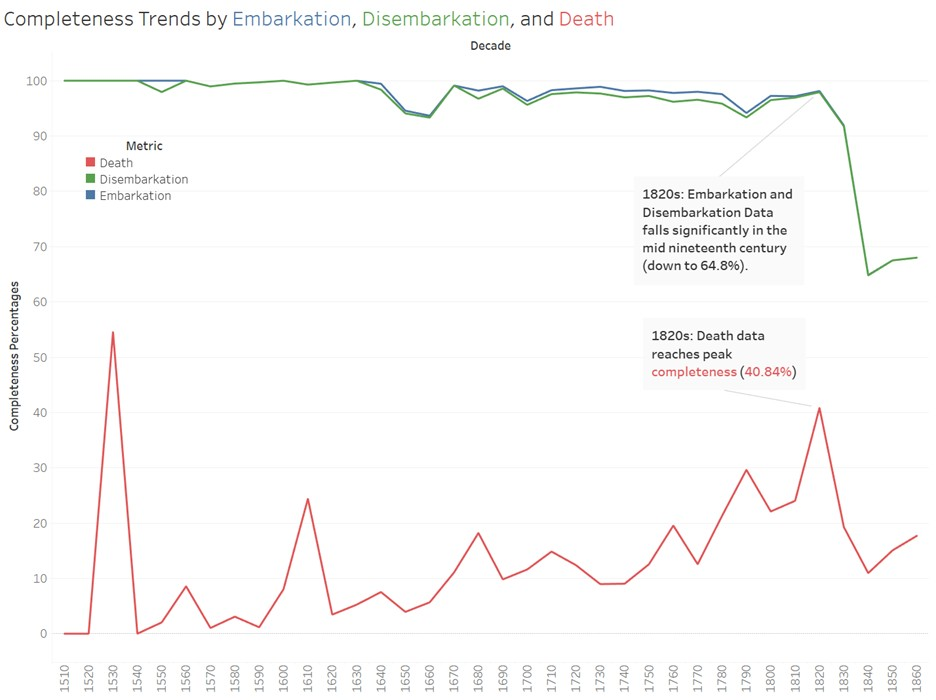

###### **Figure 1: Completeness Trends by Record Type (1510–1860)**

**Gendered Patterns Across Time**

When gender is introduced as a filter, completeness drops sharply. For both male and female passengers, embarkation and disembarkation data remain under 30% complete in all decades, with some minor gains in the late 1600s and more consistent (though still limited) entries beginning in the late 1700s. The decade of 1670 stands out briefly, with both male and female disembarkation completeness peaking at 27.70%, before falling again in subsequent decades.

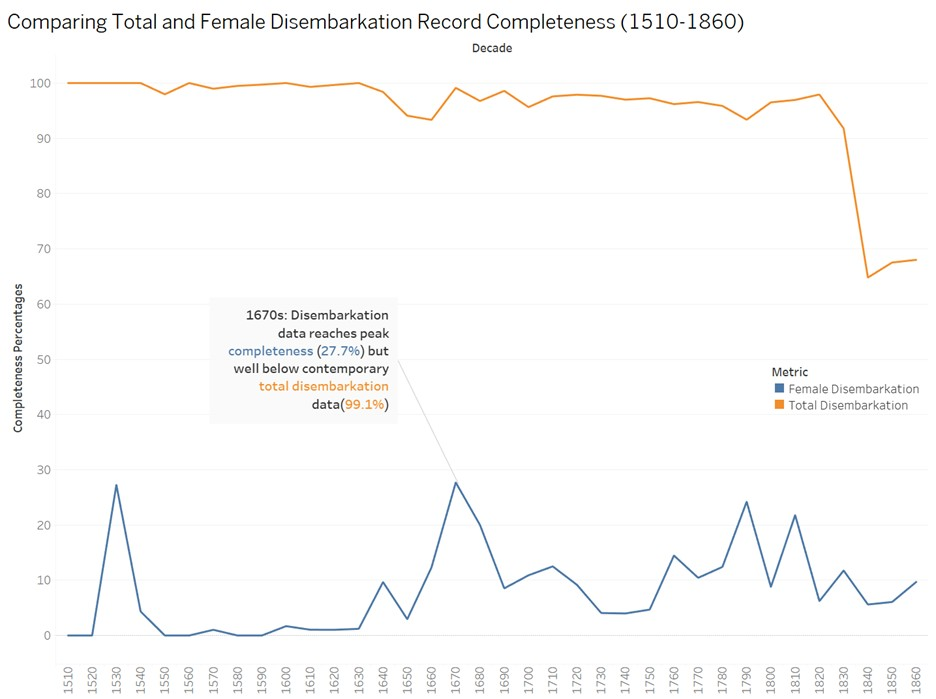

###### **Figure 2: Disembarkation completeness by decade, comparing total records to those identifying women.**

Records for girls are even scarcer. Embarkation fields for girls begin appearing in the 1640s but remain below 5% completeness for most of the timeline. Disembarkation data shows modest improvement, peaking in the 1790s (20.83%) and 1810s (21.49%). Death records for girls are essentially nonexistent; the 1790s mark the highest point, at just 1.91% completeness.

These patterns suggest that gendered demographic data becomes meaningfully available only in the late 18th and early 19th centuries. Prior to that, the dataset offers little usable information on the identities or experiences of enslaved women and girls.

**Geographic Variation in Completeness**

When filtered by gender and age, the Caribbean consistently emerges as the most data-rich region. It features the highest completeness for girl disembarkation fields and relatively better representation of female records. Other regions such as Brazil and Mainland North America show isolated gains in specific decades but lack consistent visibility for women and girls across the full dataset.

**Region-Decade Intersections**

The intersection of time and place produces clearer targets for focused analysis. The pivot tables show that certain combinations—such as the Caribbean in the 1790s—yield relatively high completeness in gendered fields, especially for girls. In contrast, Africa during the same period, while heavily trafficked, remains data-poor for gender-specific information. Brief spikes in completeness (e.g., female embarkation in Africa during the 1750s) do appear, but they lack the sustained presence needed for longitudinal study.

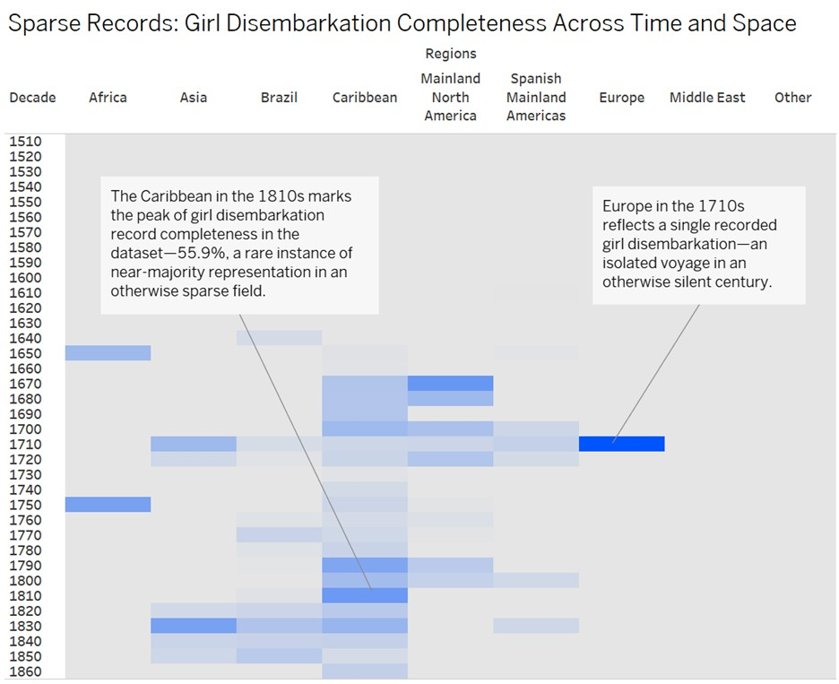

###### **Figure 3: Girl Disembarkation Completeness by Decade and Region.**

**Implications for Case Study Design**

This analysis recommends focusing case studies on regions and decades where gender and age data is most complete. The Caribbean during the 1790s and 1810s offers the strongest foundation for exploring the experiences of enslaved girls, supported by relatively high completeness in disembarkation fields. Brazil also offers useful data during this window, particularly when paired with voyage-level context. Conversely, earlier periods and African embarkation records remain fragmentary, limiting their utility for demographic study.

#### **7. Interpreting Completeness: Key Findings and Implications**

By identifying these stronger intersections of time and region, researchers can select data slices that maximize interpretive potential while maintaining historical fidelity. This approach respects the dataset’s limitations while still uncovering meaningful patterns.

The completeness audit was conducted not only to assess where data is present, but to illuminate how its distribution affects interpretive potential. By examining the dataset as a whole and then narrowing in on gender and age, this analysis illustrates both the richness and the unevenness of the historical record. The resulting patterns offer a fuller understanding of what the dataset can—and cannot—tell us about the transatlantic and intra-American slave trades.

Key findings from the audit help frame these limits and opportunities:

- **Structural fields** such as ship_name, departure_year, and tonnage_type were found to be highly complete and consistent across the dataset.
- **Demographic fields** such as gender and age were significantly less complete, especially in earlier periods or in certain regions. However, a noticeable improvement in data quality appears after 1780.
- **Completeness patterns** vary not only by variable but also by time and geography, underscoring the need for contextual awareness when using the data.

Visualizations of completeness by decade and region revealed important trends, including pockets of highly reliable demographic data and areas of systematic absence. These findings support researchers in making informed decisions about filtering, joining, or interpreting data depending on their line of inquiry.

The completeness audit ultimately serves as a decision-making tool. It empowers historians and data stewards to work with the Slave Voyages dataset more critically, helping to match the scope of a research question to the scope of available data. It also identifies areas where further data curation or enrichment could have a meaningful impact on usability.

The next and final section turns these findings toward practical application, offering recommendations for responsible use, future refinement, and continued collaboration with the dataset’s evolving structure and mission.

#### **8. Navigating the Dataset: Insights and Next Steps**

The completeness audit is not a final verdict on the Slave Voyages dataset, but rather a tool—an interpretive guide to help researchers, educators, and curators better anticipate the terrain of their inquiry. By surfacing patterns in what data is present, where gaps exist, and how completeness shifts over time and region, this project offers a framework for evaluating the analytical readiness of the archive.

For historians new to the dataset, this audit serves as a forecast: a way to assess which lines of inquiry are supported by strong underlying data and which may encounter archival silences. Rather than prescribing how the dataset should be used, the audit empowers users to make informed, responsible choices about filtering, segmenting, or combining fields in their analysis.

For data stewards and curators, the audit highlights areas of strength that can be showcased and areas of fragility that might be prioritized for future enrichment. It also serves as a repeatable model—a methodology that can be extended as the dataset grows or as new questions arise.

The final conclusion of this analysis is not numerical but practical: **completeness matters**. It shapes how research questions are framed, how results are interpreted, and how confidently insights can be shared. By making completeness visible, this project invites more transparent, more critical, and ultimately more effective engagement with one of the most important historical datasets in the digital humanities.

The next step is not to close the dataset, but to open it—to continued analysis, thoughtful use, and collaborative refinement informed by the patterns this audit has revealed.

#### **Appendix A: R Scripts and Functions**

This appendix includes a core function used during the data cleaning and standardization phase of this project. It was applied to each of the nine raw tables to enforce consistent formatting, normalize null values, and prepare the data for export and analysis.

Additional helper functions, including foreign key validators and lookup table transformations, are available in the scripts section of the project repository or upon request.

```r
clean_table <- function(df) {
  df <- df %>%

    # Trim whitespace from character columns
    mutate(across(where(is.character), stringr::str_trim)) %>%

    # Convert empty strings to NA
    mutate(across(where(is.character), ~ na_if(., ""))) %>%

    # Remove extra internal spacing from text
    mutate(across(where(is.character), stringr::str_squish)) %>%

    # Convert character text to title case
    mutate(across(where(is.character), stringr::str_to_title)) %>%

    # Standardize known data types
    mutate(voyage_id = as.integer(voyage_id)) %>%
    mutate(across(contains("date"), \(x) as.Date(x, format = "%Y-%m-%d"))) %>%
    mutate(across(where(is.numeric), as.numeric))

  # Convert 'evergreen' column to logical, if present
  if ("evergreen" %in% colnames(df)) {
    df <- df %>% mutate(evergreen = as.logical(evergreen))
  }

  # Remove duplicates based on voyage_id
  df <- df %>% distinct(voyage_id, .keep_all = TRUE)

  return(df)
}
```

#### **Appendix B: Entity Relationship Diagram (ERD)**

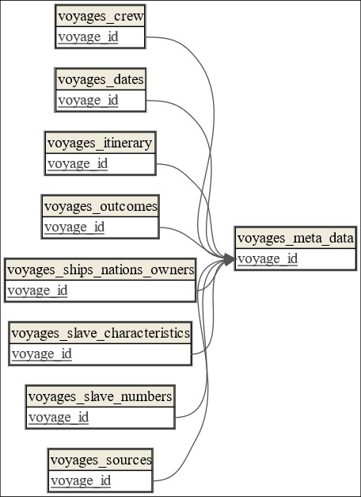

#### **Appendix C: SQL Query Library**

This appendix contains the primary SQL queries used to assess data completeness across time, geography, and demographic dimensions. The SQL Query Library is split into three separate sections:

1. Queries for chronological analysis
2. Queries for geographical analysis
3. Queries relating chronological and geographical analysis

All queries were executed in Google BigQuery and reference the cleaned relational schema described in Appendix B.

**Query: Completeness by Decade**

```sql
-- Total Embarkation by Decade
SELECT
  FLOOR(d.voyage_start_imputed_year / 10) * 10 AS decade,
  COUNT(s.slaves_embarked_total) / COUNT(*) * 100 AS embarkation_completeness_pct
FROM `slave_voyages.voyages_slave_numbers` s
JOIN `slave_voyages.voyages_dates` d
  ON s.voyage_id = d.voyage_id
GROUP BY decade
ORDER BY decade;

-- Total Disembarkation by Decade
SELECT
  FLOOR(d.voyage_start_imputed_year / 10) * 10 AS decade,
  COUNT(s.slaves_disembarked_total) / COUNT(*) * 100 AS disembarkation_completeness_pct
FROM `slave_voyages.voyages_slave_numbers` s
JOIN `slave_voyages.voyages_dates` d
  ON s.voyage_id = d.voyage_id
GROUP BY decade
ORDER BY decade;

-- Total Deaths Completeness by Decade
SELECT
  FLOOR(d.voyage_start_imputed_year / 10) * 10 AS decade,
  COUNT(c.slave_death_total_derived) / COUNT(*) * 100 AS death_completeness_pct
FROM `slave_voyages.voyages_slave_characteristics` c
JOIN `slave_voyages.voyages_dates` d
  ON c.voyage_id = d.voyage_id
GROUP BY decade
ORDER BY decade;

-- Male vs Female Embarkation Completeness by Decade
SELECT
  FLOOR(d.voyage_start_imputed_year / 10) * 10 AS decade,
  COUNT(c.male_embark_total) / COUNT(*) * 100 AS male_embark_pct,
  COUNT(c.female_embark_total) / COUNT(*) * 100 AS female_embark_pct
FROM `slave_voyages.voyages_slave_characteristics` c
JOIN `slave_voyages.voyages_dates` d
  ON c.voyage_id = d.voyage_id
GROUP BY decade
ORDER BY decade;

-- Male vs Female Disembarkation Completeness by Decade
SELECT
  FLOOR(d.voyage_start_imputed_year / 10) * 10 AS decade,
  COUNT(c.male_arrival_total) / COUNT(*) * 100 AS male_disembark_pct,
  COUNT(c.female_arrival_total) / COUNT(*) * 100 AS female_disembark_pct
FROM `slave_voyages.voyages_slave_characteristics` c
JOIN `slave_voyages.voyages_dates` d
  ON c.voyage_id = d.voyage_id
GROUP BY decade
ORDER BY decade;

-- Male vs Female Deaths Completeness by Decade
SELECT
  FLOOR(d.voyage_start_imputed_year / 10) * 10 AS decade,
  COUNT(c.male_death_passage) / COUNT(*) * 100 AS male_death_pct,
  COUNT(c.female_death_passage) / COUNT(*) * 100 AS female_death_pct
FROM `slave_voyages.voyages_slave_characteristics` c
JOIN `slave_voyages.voyages_dates` d
  ON c.voyage_id = d.voyage_id
GROUP BY decade
ORDER BY decade;

-- Girl Embarkation Completeness by Decade
SELECT
  FLOOR(d.voyage_start_imputed_year / 10) * 10 AS decade,
  COUNT(c.girl_embark_port1) / COUNT(*) * 100 AS girl_embark_pct
FROM `slave_voyages.voyages_slave_characteristics` c
JOIN `slave_voyages.voyages_dates` d
  ON c.voyage_id = d.voyage_id
GROUP BY decade
ORDER BY decade;

-- Girl Disembarkation Completeness by Decade
SELECT
  FLOOR(d.voyage_start_imputed_year / 10) * 10 AS decade,
  COUNT(c.girl_arrival_total) / COUNT(*) * 100 AS girl_disembark_pct
FROM `slave_voyages.voyages_slave_characteristics` c
JOIN `slave_voyages.voyages_dates` d
  ON c.voyage_id = d.voyage_id
GROUP BY decade
ORDER BY decade;

-- Girl Deaths Completeness by Decade
SELECT
  FLOOR(d.voyage_start_imputed_year / 10) * 10 AS decade,
  COUNT(c.girl_died_passage) / COUNT(*) * 100 AS girl_death_pct
FROM `slave_voyages.voyages_slave_characteristics` c
JOIN `slave_voyages.voyages_dates` d
  ON c.voyage_id = d.voyage_id
GROUP BY decade
ORDER BY decade;
```

**Query: Completeness by Region**

```sql
-- Total Disembarkation Completeness by Broad Region
WITH disembark_regions AS (
  SELECT
    i.voyage_id,
    CAST(SUBSTR(CAST(i.primary_disembark_port AS STRING), 0, 1) AS INT64) * 10000 AS broad_region_code
  FROM `slave_voyages.voyages_itinerary` i
  WHERE i.primary_disembark_port IS NOT NULL
),
labeled_regions AS (
  SELECT DISTINCT broad_region_value, broad_region
  FROM `slave_voyages.lookup_voyages_geographic_codes`
),
completeness AS (
  SELECT
    r.broad_region,
    COUNT(s.slaves_disembarked_total) / COUNT(*) * 100 AS disembarkation_completeness_pct
  FROM `slave_voyages.voyages_slave_numbers` s
  JOIN disembark_regions i ON s.voyage_id = i.voyage_id
  JOIN labeled_regions r ON i.broad_region_code = r.broad_region_value
  GROUP BY r.broad_region
)
SELECT * FROM completeness
ORDER BY disembarkation_completeness_pct DESC;

-- Total Embarkation Completeness by Broad Region
WITH disembark_regions AS (
  SELECT
    i.voyage_id,
    CAST(SUBSTR(CAST(i.primary_disembark_port AS STRING), 0, 1) AS INT64) * 10000 AS broad_region_code
  FROM `slave_voyages.voyages_itinerary` i
  WHERE i.primary_disembark_port IS NOT NULL
),
labeled_regions AS (
  SELECT DISTINCT broad_region_value, broad_region
  FROM `slave_voyages.lookup_voyages_geographic_codes`
),
completeness AS (
  SELECT
    r.broad_region,
    COUNT(s.slaves_embarked_total) / COUNT(*) * 100 AS embarkation_completeness_pct
  FROM `slave_voyages.voyages_slave_numbers` s
  JOIN disembark_regions i ON s.voyage_id = i.voyage_id
  JOIN labeled_regions r ON i.broad_region_code = r.broad_region_value
  GROUP BY r.broad_region
)
SELECT * FROM completeness
ORDER BY embarkation_completeness_pct DESC;

-- Total Deaths Completeness by Broad Region
WITH disembark_regions AS (
  SELECT
    i.voyage_id,
    CAST(SUBSTR(CAST(i.primary_disembark_port AS STRING), 0, 1) AS INT64) * 10000 AS broad_region_code
  FROM `slave_voyages.voyages_itinerary` i
  WHERE i.primary_disembark_port IS NOT NULL
),
labeled_regions AS (
  SELECT DISTINCT broad_region_value, broad_region
  FROM `slave_voyages.lookup_voyages_geographic_codes`
),
completeness AS (
  SELECT
    r.broad_region,
    COUNT(c.slave_death_total_derived) / COUNT(*) * 100 AS death_completeness_pct
  FROM `slave_voyages.voyages_slave_characteristics` c
  JOIN disembark_regions i ON c.voyage_id = i.voyage_id
  JOIN labeled_regions r ON i.broad_region_code = r.broad_region_value
  GROUP BY r.broad_region
)
SELECT * FROM completeness
ORDER BY death_completeness_pct DESC;

-- Male vs Female Embarkation Completeness by Broad Region
WITH disembark_regions AS (
  SELECT
    i.voyage_id,
    CAST(SUBSTR(CAST(i.primary_disembark_port AS STRING), 0, 1) AS INT64) * 10000 AS broad_region_code
  FROM `slave_voyages.voyages_itinerary` i
  WHERE i.primary_disembark_port IS NOT NULL
),
labeled_regions AS (
  SELECT DISTINCT broad_region_value, broad_region
  FROM `slave_voyages.lookup_voyages_geographic_codes`
),
completeness AS (
  SELECT
    r.broad_region,
    COUNT(c.male_embark_total) / COUNT(*) * 100 AS male_embark_pct,
    COUNT(c.female_embark_total) / COUNT(*) * 100 AS female_embark_pct
  FROM `slave_voyages.voyages_slave_characteristics` c
  JOIN disembark_regions i ON c.voyage_id = i.voyage_id
  JOIN labeled_regions r ON i.broad_region_code = r.broad_region_value
  GROUP BY r.broad_region
)
SELECT * FROM completeness
ORDER BY broad_region;

-- Male vs Female Disembarkation Completeness by Broad Region
WITH disembark_regions AS (
  SELECT
    i.voyage_id,
    CAST(SUBSTR(CAST(i.primary_disembark_port AS STRING), 0, 1) AS INT64) * 10000 AS broad_region_code
  FROM `slave_voyages.voyages_itinerary` i
  WHERE i.primary_disembark_port IS NOT NULL
),
labeled_regions AS (
  SELECT DISTINCT broad_region_value, broad_region
  FROM `slave_voyages.lookup_voyages_geographic_codes`
),
completeness AS (
  SELECT
    r.broad_region,
    COUNT(c.male_arrival_total) / COUNT(*) * 100 AS male_disembark_pct,
    COUNT(c.female_arrival_total) / COUNT(*) * 100 AS female_disembark_pct
  FROM `slave_voyages.voyages_slave_characteristics` c
  JOIN disembark_regions i ON c.voyage_id = i.voyage_id
  JOIN labeled_regions r ON i.broad_region_code = r.broad_region_value
  GROUP BY r.broad_region
)
SELECT * FROM completeness
ORDER BY broad_region;

-- Male vs Female Deaths Completeness by Broad Region
WITH disembark_regions AS (
  SELECT
    i.voyage_id,
    CAST(SUBSTR(CAST(i.primary_disembark_port AS STRING), 0, 1) AS INT64) * 10000 AS broad_region_code
  FROM `slave_voyages.voyages_itinerary` i
  WHERE i.primary_disembark_port IS NOT NULL
),
labeled_regions AS (
  SELECT DISTINCT broad_region_value, broad_region
  FROM `slave_voyages.lookup_voyages_geographic_codes`
),
completeness AS (
  SELECT
    r.broad_region,
    COUNT(c.male_death_passage) / COUNT(*) * 100 AS male_death_pct,
    COUNT(c.female_death_passage) / COUNT(*) * 100 AS female_death_pct
  FROM `slave_voyages.voyages_slave_characteristics` c
  JOIN disembark_regions i ON c.voyage_id = i.voyage_id
  JOIN labeled_regions r ON i.broad_region_code = r.broad_region_value
  GROUP BY r.broad_region
)
SELECT * FROM completeness
ORDER BY broad_region;

-- Girl Embarkation Completeness by Broad Region
WITH disembark_regions AS (
  SELECT
    i.voyage_id,
    CAST(SUBSTR(CAST(i.primary_disembark_port AS STRING), 0, 1) AS INT64) * 10000 AS broad_region_code
  FROM `slave_voyages.voyages_itinerary` i
  WHERE i.primary_disembark_port IS NOT NULL
),
labeled_regions AS (
  SELECT DISTINCT broad_region_value, broad_region
  FROM `slave_voyages.lookup_voyages_geographic_codes`
),
completeness AS (
  SELECT
    r.broad_region,
    COUNT(c.girl_embark_port1) / COUNT(*) * 100 AS girl_embark_pct
  FROM `slave_voyages.voyages_slave_characteristics` c
  JOIN disembark_regions i ON c.voyage_id = i.voyage_id
  JOIN labeled_regions r ON i.broad_region_code = r.broad_region_value
  GROUP BY r.broad_region
)
SELECT * FROM completeness
ORDER BY broad_region;

-- Girl Disembarkation Completeness by Broad Region
WITH disembark_regions AS (
  SELECT
    i.voyage_id,
    CAST(SUBSTR(CAST(i.primary_disembark_port AS STRING), 0, 1) AS INT64) * 10000 AS broad_region_code
  FROM `slave_voyages.voyages_itinerary` i
  WHERE i.primary_disembark_port IS NOT NULL
),
labeled_regions AS (
  SELECT DISTINCT broad_region_value, broad_region
  FROM `slave_voyages.lookup_voyages_geographic_codes`
),
completeness AS (
  SELECT
    r.broad_region,
    COUNT(c.girl_arrival_total) / COUNT(*) * 100 AS girl_disembark_pct
  FROM `slave_voyages.voyages_slave_characteristics` c
  JOIN disembark_regions i ON c.voyage_id = i.voyage_id
  JOIN labeled_regions r ON i.broad_region_code = r.broad_region_value
  GROUP BY r.broad_region
)
SELECT * FROM completeness
ORDER BY broad_region;

-- Girl Deaths Completeness by Broad Region
WITH disembark_regions AS (
  SELECT
    i.voyage_id,
    CAST(SUBSTR(CAST(i.primary_disembark_port AS STRING), 0, 1) AS INT64) * 10000 AS broad_region_code
  FROM `slave_voyages.voyages_itinerary` i
  WHERE i.primary_disembark_port IS NOT NULL
),
labeled_regions AS (
  SELECT DISTINCT broad_region_value, broad_region
  FROM `slave_voyages.lookup_voyages_geographic_codes`
),
completeness AS (
  SELECT
    r.broad_region,
    COUNT(c.girl_died_passage) / COUNT(*) * 100 AS girl_death_pct
  FROM `slave_voyages.voyages_slave_characteristics` c
  JOIN disembark_regions i ON c.voyage_id = i.voyage_id
  JOIN labeled_regions r ON i.broad_region_code = r.broad_region_value
  GROUP BY r.broad_region
)
SELECT * FROM completeness
ORDER BY broad_region;
```

**Query: Completeness by Decade and Region**

```sql
-- Total Embarkation Completeness by Decade with Broad Regions as Columns
WITH disembark_regions AS (
  SELECT
    i.voyage_id,
    FLOOR(d.voyage_start_imputed_year / 10) * 10 AS decade,
    CAST(SUBSTR(CAST(i.primary_disembark_port AS STRING), 1, 1) AS INT64) * 10000 AS broad_region_code
  FROM `slave_voyages.voyages_itinerary` i
  JOIN `slave_voyages.voyages_dates` d ON i.voyage_id = d.voyage_id
  WHERE i.primary_disembark_port IS NOT NULL
),
labeled_regions AS (
  SELECT DISTINCT broad_region_value, broad_region
  FROM `slave_voyages.lookup_voyages_geographic_codes`
),
distinct_decades AS (
  SELECT DISTINCT FLOOR(voyage_start_imputed_year / 10) * 10 AS decade
  FROM `slave_voyages.voyages_dates`
),
all_combinations AS (
  SELECT d.decade, r.broad_region
  FROM distinct_decades d
  CROSS JOIN (SELECT DISTINCT broad_region FROM labeled_regions) r
),
percent_complete AS (
  SELECT
    r.broad_region,
    i.decade,
    COUNT(s.slaves_embarked_total) / COUNT(*) * 100 AS completeness_pct
  FROM `slave_voyages.voyages_slave_numbers` s
  JOIN disembark_regions i ON s.voyage_id = i.voyage_id
  JOIN labeled_regions r ON i.broad_region_code = r.broad_region_value
  GROUP BY r.broad_region, i.decade
),
filled_data AS (
  SELECT
    a.decade,
    a.broad_region,
    IFNULL(p.completeness_pct, 0) AS completeness_pct
  FROM all_combinations a
  LEFT JOIN percent_complete p ON a.decade = p.decade AND a.broad_region = p.broad_region
)
SELECT * FROM filled_data
PIVOT (
  MAX(completeness_pct)
  FOR broad_region IN (
    'Europe',
    'Mainland North America',
    'Caribbean',
    'Spanish Mainland Americas',
    'Brazil',
    'Africa',
    'Middle East',
    'Asia',
    'Other'
  )
)
ORDER BY decade;

-- Total Disembarkation Completeness by Decade with Broad Regions as Columns
WITH disembark_regions AS (
  SELECT
    i.voyage_id,
    FLOOR(d.voyage_start_imputed_year / 10) * 10 AS decade,
    CAST(SUBSTR(CAST(i.primary_disembark_port AS STRING), 1, 1) AS INT64) * 10000 AS broad_region_code
  FROM `slave_voyages.voyages_itinerary` i
  JOIN `slave_voyages.voyages_dates` d ON i.voyage_id = d.voyage_id
  WHERE i.primary_disembark_port IS NOT NULL
),
labeled_regions AS (
  SELECT DISTINCT broad_region_value, broad_region
  FROM `slave_voyages.lookup_voyages_geographic_codes`
),
distinct_decades AS (
  SELECT DISTINCT FLOOR(voyage_start_imputed_year / 10) * 10 AS decade
  FROM `slave_voyages.voyages_dates`
),
all_combinations AS (
  SELECT d.decade, r.broad_region
  FROM distinct_decades d
  CROSS JOIN (SELECT DISTINCT broad_region FROM labeled_regions) r
),
percent_complete AS (
  SELECT
    r.broad_region,
    i.decade,
    COUNT(s.slaves_disembarked_total) / COUNT(*) * 100 AS completeness_pct
  FROM `slave_voyages.voyages_slave_numbers` s
  JOIN disembark_regions i ON s.voyage_id = i.voyage_id
  JOIN labeled_regions r ON i.broad_region_code = r.broad_region_value
  GROUP BY r.broad_region, i.decade
),
filled_data AS (
  SELECT
    a.decade,
    a.broad_region,
    IFNULL(p.completeness_pct, 0) AS completeness_pct
  FROM all_combinations a
  LEFT JOIN percent_complete p ON a.decade = p.decade AND a.broad_region = p.broad_region
)
SELECT * FROM filled_data
PIVOT (
  MAX(completeness_pct)
  FOR broad_region IN (
    'Europe',
    'Mainland North America',
    'Caribbean',
    'Spanish Mainland Americas',
    'Brazil',
    'Africa',
    'Middle East',
    'Asia',
    'Other'
  )
)
ORDER BY decade;

-- Total Deaths Completeness by Decade with Broad Regions as Columns
WITH disembark_regions AS (
  SELECT
    i.voyage_id,
    FLOOR(d.voyage_start_imputed_year / 10) * 10 AS decade,
    CAST(SUBSTR(CAST(i.primary_disembark_port AS STRING), 1, 1) AS INT64) * 10000 AS broad_region_code
  FROM `slave_voyages.voyages_itinerary` i
  JOIN `slave_voyages.voyages_dates` d ON i.voyage_id = d.voyage_id
  WHERE i.primary_disembark_port IS NOT NULL
),
labeled_regions AS (
  SELECT DISTINCT broad_region_value, broad_region
  FROM `slave_voyages.lookup_voyages_geographic_codes`
),
distinct_decades AS (
  SELECT DISTINCT FLOOR(voyage_start_imputed_year / 10) * 10 AS decade
  FROM `slave_voyages.voyages_dates`
),
all_combinations AS (
  SELECT d.decade, r.broad_region
  FROM distinct_decades d
  CROSS JOIN (SELECT DISTINCT broad_region FROM labeled_regions) r
),
percent_complete AS (
  SELECT
    r.broad_region,
    i.decade,
    COUNT(c.slave_death_total_derived) / COUNT(*) * 100 AS completeness_pct
  FROM `slave_voyages.voyages_slave_characteristics` c
  JOIN disembark_regions i ON c.voyage_id = i.voyage_id
  JOIN labeled_regions r ON i.broad_region_code = r.broad_region_value
  GROUP BY r.broad_region, i.decade
),
filled_data AS (
  SELECT
    a.decade,
    a.broad_region,
    IFNULL(p.completeness_pct, 0) AS completeness_pct
  FROM all_combinations a
  LEFT JOIN percent_complete p ON a.decade = p.decade AND a.broad_region = p.broad_region
)
SELECT * FROM filled_data
PIVOT (
  MAX(completeness_pct)
  FOR broad_region IN (
    'Europe',
    'Mainland North America',
    'Caribbean',
    'Spanish Mainland Americas',
    'Brazil',
    'Africa',
    'Middle East',
    'Asia',
    'Other'
  )
)
ORDER BY decade;

-- Female Embarkation Completeness by Decade with Broad Regions as Columns
WITH disembark_regions AS (
  SELECT
    i.voyage_id,
    FLOOR(d.voyage_start_imputed_year / 10) * 10 AS decade,
    CAST(SUBSTR(CAST(i.primary_disembark_port AS STRING), 1, 1) AS INT64) * 10000 AS broad_region_code
  FROM `slave_voyages.voyages_itinerary` i
  JOIN `slave_voyages.voyages_dates` d ON i.voyage_id = d.voyage_id
  WHERE i.primary_disembark_port IS NOT NULL
),
labeled_regions AS (
  SELECT DISTINCT broad_region_value, broad_region
  FROM `slave_voyages.lookup_voyages_geographic_codes`
),
distinct_decades AS (
  SELECT DISTINCT FLOOR(voyage_start_imputed_year / 10) * 10 AS decade
  FROM `slave_voyages.voyages_dates`
),
all_combinations AS (
  SELECT d.decade, r.broad_region
  FROM distinct_decades d
  CROSS JOIN (SELECT DISTINCT broad_region FROM labeled_regions) r
),
percent_complete AS (
  SELECT
    r.broad_region,
    i.decade,
    COUNT(c.female_embark_total) / COUNT(*) * 100 AS completeness_pct
  FROM `slave_voyages.voyages_slave_characteristics` c
  JOIN disembark_regions i ON c.voyage_id = i.voyage_id
  JOIN labeled_regions r ON i.broad_region_code = r.broad_region_value
  GROUP BY r.broad_region, i.decade
),
filled_data AS (
  SELECT
    a.decade,
    a.broad_region,
    IFNULL(p.completeness_pct, 0) AS completeness_pct
  FROM all_combinations a
  LEFT JOIN percent_complete p ON a.decade = p.decade AND a.broad_region = p.broad_region
)
SELECT * FROM filled_data
PIVOT (
  MAX(completeness_pct)
  FOR broad_region IN (
    'Europe',
    'Mainland North America',
    'Caribbean',
    'Spanish Mainland Americas',
    'Brazil',
    'Africa',
    'Middle East',
    'Asia',
    'Other'
  )
)
ORDER BY decade;
```

```sql
-- Female Disembarkation Completeness by Decade with Broad Regions as Columns
WITH disembark_regions AS (
  SELECT
    i.voyage_id,
    FLOOR(d.voyage_start_imputed_year / 10) * 10 AS decade,
    CAST(SUBSTR(CAST(i.primary_disembark_port AS STRING), 1, 1) AS INT64) * 10000 AS broad_region_code
  FROM `slave_voyages.voyages_itinerary` i
  JOIN `slave_voyages.voyages_dates` d ON i.voyage_id = d.voyage_id
  WHERE i.primary_disembark_port IS NOT NULL
),
labeled_regions AS (
  SELECT DISTINCT broad_region_value, broad_region
  FROM `slave_voyages.lookup_voyages_geographic_codes`
),
distinct_decades AS (
  SELECT DISTINCT FLOOR(voyage_start_imputed_year / 10) * 10 AS decade
  FROM `slave_voyages.voyages_dates`
),
all_combinations AS (
  SELECT d.decade, r.broad_region
  FROM distinct_decades d
  CROSS JOIN (SELECT DISTINCT broad_region FROM labeled_regions) r
),
percent_complete AS (
  SELECT
    r.broad_region,
    i.decade,
    COUNT(c.female_arrival_total) / COUNT(*) * 100 AS completeness_pct
  FROM `slave_voyages.voyages_slave_characteristics` c
  JOIN disembark_regions i ON c.voyage_id = i.voyage_id
  JOIN labeled_regions r ON i.broad_region_code = r.broad_region_value
  GROUP BY r.broad_region, i.decade
),
filled_data AS (
  SELECT
    a.decade,
    a.broad_region,
    IFNULL(p.completeness_pct, 0) AS completeness_pct
  FROM all_combinations a
  LEFT JOIN percent_complete p ON a.decade = p.decade AND a.broad_region = p.broad_region
)
SELECT * FROM filled_data
PIVOT (
  MAX(completeness_pct)
  FOR broad_region IN (
    'Europe',
    'Mainland North America',
    'Caribbean',
    'Spanish Mainland Americas',
    'Brazil',
    'Africa',
    'Middle East',
    'Asia',
    'Other'
  )
)
ORDER BY decade;

-- Female Deaths Completeness by Decade with Broad Regions as Columns
WITH disembark_regions AS (
  SELECT
    i.voyage_id,
    FLOOR(d.voyage_start_imputed_year / 10) * 10 AS decade,
    CAST(SUBSTR(CAST(i.primary_disembark_port AS STRING), 1, 1) AS INT64) * 10000 AS broad_region_code
  FROM `slave_voyages.voyages_itinerary` i
  JOIN `slave_voyages.voyages_dates` d ON i.voyage_id = d.voyage_id
  WHERE i.primary_disembark_port IS NOT NULL
),
labeled_regions AS (
  SELECT DISTINCT broad_region_value, broad_region
  FROM `slave_voyages.lookup_voyages_geographic_codes`
),
distinct_decades AS (
  SELECT DISTINCT FLOOR(voyage_start_imputed_year / 10) * 10 AS decade
  FROM `slave_voyages.voyages_dates`
),
all_combinations AS (
  SELECT d.decade, r.broad_region
  FROM distinct_decades d
  CROSS JOIN (SELECT DISTINCT broad_region FROM labeled_regions) r
),
percent_complete AS (
  SELECT
    r.broad_region,
    i.decade,
    COUNT(c.female_death_passage) / COUNT(*) * 100 AS completeness_pct
  FROM `slave_voyages.voyages_slave_characteristics` c
  JOIN disembark_regions i ON c.voyage_id = i.voyage_id
  JOIN labeled_regions r ON i.broad_region_code = r.broad_region_value
  GROUP BY r.broad_region, i.decade
),
filled_data AS (
  SELECT
    a.decade,
    a.broad_region,
    IFNULL(p.completeness_pct, 0) AS completeness_pct
  FROM all_combinations a
  LEFT JOIN percent_complete p ON a.decade = p.decade AND a.broad_region = p.broad_region
)
SELECT * FROM filled_data
PIVOT (
  MAX(completeness_pct)
  FOR broad_region IN (
    'Europe',
    'Mainland North America',
    'Caribbean',
    'Spanish Mainland Americas',
    'Brazil',
    'Africa',
    'Middle East',
    'Asia',
    'Other'
  )
)
ORDER BY decade;

-- Girl Embarkation Completeness by Decade with Broad Regions as Columns
WITH disembark_regions AS (
  SELECT
    i.voyage_id,
    FLOOR(d.voyage_start_imputed_year / 10) * 10 AS decade,
    CAST(SUBSTR(CAST(i.primary_disembark_port AS STRING), 1, 1) AS INT64) * 10000 AS broad_region_code
  FROM `slave_voyages.voyages_itinerary` i
  JOIN `slave_voyages.voyages_dates` d ON i.voyage_id = d.voyage_id
  WHERE i.primary_disembark_port IS NOT NULL
),
labeled_regions AS (
  SELECT DISTINCT broad_region_value, broad_region
  FROM `slave_voyages.lookup_voyages_geographic_codes`
),
distinct_decades AS (
  SELECT DISTINCT FLOOR(voyage_start_imputed_year / 10) * 10 AS decade
  FROM `slave_voyages.voyages_dates`
),
all_combinations AS (
  SELECT d.decade, r.broad_region
  FROM distinct_decades d
  CROSS JOIN (SELECT DISTINCT broad_region FROM labeled_regions) r
),
percent_complete AS (
  SELECT
    r.broad_region,
    i.decade,
    COUNT(c.girl_embark_port1) / COUNT(*) * 100 AS completeness_pct
  FROM `slave_voyages.voyages_slave_characteristics` c
  JOIN disembark_regions i ON c.voyage_id = i.voyage_id
  JOIN labeled_regions r ON i.broad_region_code = r.broad_region_value
  GROUP BY r.broad_region, i.decade
),
filled_data AS (
  SELECT
    a.decade,
    a.broad_region,
    IFNULL(p.completeness_pct, 0) AS completeness_pct
  FROM all_combinations a
  LEFT JOIN percent_complete p ON a.decade = p.decade AND a.broad_region = p.broad_region
)
SELECT * FROM filled_data
PIVOT (
  MAX(completeness_pct)
  FOR broad_region IN (
    'Europe',
    'Mainland North America',
    'Caribbean',
    'Spanish Mainland Americas',
    'Brazil',
    'Africa',
    'Middle East',
    'Asia',
    'Other'
  )
)
ORDER BY decade;

-- Girl Disembarkation Completeness by Decade with Broad Regions as Columns
WITH disembark_regions AS (
  SELECT
    i.voyage_id,
    FLOOR(d.voyage_start_imputed_year / 10) * 10 AS decade,
    CAST(SUBSTR(CAST(i.primary_disembark_port AS STRING), 1, 1) AS INT64) * 10000 AS broad_region_code
  FROM `slave_voyages.voyages_itinerary` i
  JOIN `slave_voyages.voyages_dates` d ON i.voyage_id = d.voyage_id
  WHERE i.primary_disembark_port IS NOT NULL
),
labeled_regions AS (
  SELECT DISTINCT broad_region_value, broad_region
  FROM `slave_voyages.lookup_voyages_geographic_codes`
),
distinct_decades AS (
  SELECT DISTINCT FLOOR(voyage_start_imputed_year / 10) * 10 AS decade
  FROM `slave_voyages.voyages_dates`
),
all_combinations AS (
  SELECT d.decade, r.broad_region
  FROM distinct_decades d
  CROSS JOIN (SELECT DISTINCT broad_region FROM labeled_regions) r
),
percent_complete AS (
  SELECT
    r.broad_region,
    i.decade,
    COUNT(c.girl_arrival_total) / COUNT(*) * 100 AS completeness_pct
  FROM `slave_voyages.voyages_slave_characteristics` c
  JOIN disembark_regions i ON c.voyage_id = i.voyage_id
  JOIN labeled_regions r ON i.broad_region_code = r.broad_region_value
  GROUP BY r.broad_region, i.decade
),
filled_data AS (
  SELECT
    a.decade,
    a.broad_region,
    IFNULL(p.completeness_pct, 0) AS completeness_pct
  FROM all_combinations a
  LEFT JOIN percent_complete p ON a.decade = p.decade AND a.broad_region = p.broad_region
)
SELECT * FROM filled_data
PIVOT (
  MAX(completeness_pct)
  FOR broad_region IN (
    'Europe',
    'Mainland North America',
    'Caribbean',
    'Spanish Mainland Americas',
    'Brazil',
    'Africa',
    'Middle East',
    'Asia',
    'Other'
  )
)
ORDER BY decade;
```

```sql
-- Girl Deaths Completeness by Decade with Broad Regions as Columns
WITH disembark_regions AS (
  SELECT
    i.voyage_id,
    FLOOR(d.voyage_start_imputed_year / 10) * 10 AS decade,
    CAST(SUBSTR(CAST(i.primary_disembark_port AS STRING), 1, 1) AS INT64) * 10000 AS broad_region_code
  FROM `slave_voyages.voyages_itinerary` i
  JOIN `slave_voyages.voyages_dates` d ON i.voyage_id = d.voyage_id
  WHERE i.primary_disembark_port IS NOT NULL
),
labeled_regions AS (
  SELECT DISTINCT broad_region_value, broad_region
  FROM `slave_voyages.lookup_voyages_geographic_codes`
),
distinct_decades AS (
  SELECT DISTINCT FLOOR(voyage_start_imputed_year / 10) * 10 AS decade
  FROM `slave_voyages.voyages_dates`
),
all_combinations AS (
  SELECT d.decade, r.broad_region
  FROM distinct_decades d
  CROSS JOIN (SELECT DISTINCT broad_region FROM labeled_regions) r
),
percent_complete AS (
  SELECT
    r.broad_region,
    i.decade,
    COUNT(c.girl_died_passage) / COUNT(*) * 100 AS completeness_pct
  FROM `slave_voyages.voyages_slave_characteristics` c
  JOIN disembark_regions i ON c.voyage_id = i.voyage_id
  JOIN labeled_regions r ON i.broad_region_code = r.broad_region_value
  GROUP BY r.broad_region, i.decade
),
filled_data AS (
  SELECT
    a.decade,
    a.broad_region,
    IFNULL(p.completeness_pct, 0) AS completeness_pct
  FROM all_combinations a
  LEFT JOIN percent_complete p ON a.decade = p.decade AND a.broad_region = p.broad_region
)
SELECT * FROM filled_data
PIVOT (
  MAX(completeness_pct)
  FOR broad_region IN (
    'Europe',
    'Mainland North America',
    'Caribbean',
    'Spanish Mainland Americas',
    'Brazil',
    'Africa',
    'Middle East',
    'Asia',
    'Other'
  )
)
ORDER BY decade;
```

#### **Appendix D: Bulk Completeness Scorecards**

**1. Slave Voyages Meta Data**

| voyage_id | 100.00 |
| --- | --- |
| evergreen | 100.00 |
| voyage_grouping_code | 99.67 |
| voyage_grouping | 99.25 |

**2. Slave Voyages Ships, Nations, and Owners Data**

| ship_name | 95.47 |
| --- | --- |
| nationality_imputed | 93.94 |
| nationality | 73.58 |
| rig_type | 65.62 |
| primary_owner | 60.05 |
| tonnage | 48.93 |
| tonnage_imputed | 46.26 |
| tonnage_type | 46.05 |
| construction_place | 25.48 |
| construction_region | 25.13 |
| secondary_owner | 21.42 |
| registration_place | 20.91 |
| registration_region | 20.81 |
| year_constructed | 17.34 |
| gun_count | 17.13 |
| registration_year | 13.62 |
| tertiary_owner | 11.42 |
| fourth_owner | 7.47 |
| fifth_owner | 5.17 |
| sixth_owner | 3.62 |
| seventh_owner | 2.23 |
| eighth_owner | 1.26 |
| ninth_owner | 0.53 |
| tenth_owner | 0.26 |
| eleventh_owner | 0.09 |
| twelfth_owner | 0.04 |
| thirteenth_owner | 0.04 |
| fifteenth_owner | 0.01 |
| sixteenth_owner | 0.01 |
| fourteenth_owner | 0.01 |

**3. Slave Voyages Outcome Data**

| voyage_outcome_code | 100.00 |
| --- | --- |
| owner_outcome_code | 100.00 |
| slave_outcome_code | 100.00 |
| capture_outcome_code | 100.00 |
| african_resistance_outcome_code | 1.58 |

**4. Slave Voyages Itinerary Data**

| purchase_location_imputed_broad_region | 95.33 |
| --- | --- |
| purchase_location_imputed_place | 95.33 |
| purchase_location_imputed_region | 95.33 |
| disembark_port_imputed_broad_region | 88.19 |
| disembark_port_imputed_place | 88.19 |
| disembark_port_imputed_region | 88.18 |
| departure_region | 87.61 |
| departure_port_imputed | 87.61 |
| departure_broad_region | 87.61 |
| departure_port | 80.75 |
| primary_sale_location | 71.24 |
| disembark_region_1 | 71.23 |
| primary_sale_port | 71.19 |
| embark_region_1 | 61.14 |
| primary_purchase_location | 61.12 |
| primary_purchase_port | 60.81 |
| primary_embark_port | 43.54 |
| primary_embark_region | 43.36 |
| return_port | 29.78 |
| return_broad_region | 29.66 |
| return_region | 29.26 |
| primary_disembark_port | 28.80 |
| primary_disembark_region | 28.71 |
| num_ports_before_purchase | 9.62 |
| num_ports_americas_before_sale | 8.58 |
| secondary_purchase_location | 7.73 |
| embark_region_2 | 7.71 |
| port_before_crossing | 4.66 |
| secondary_sale_location | 3.71 |
| disembark_region_2 | 3.70 |
| secondary_embark_port | 2.71 |
| secondary_embark_region | 2.70 |
| embark_region_3 | 1.53 |
| tertiary_purchase_location | 1.53 |
| secondary_disembark_port | 0.43 |
| secondary_disembark_region | 0.42 |
| tertiary_sale_location | 0.24 |
| disembark_region_3 | 0.24 |

**5. Slave Voyages Dates Data**

| voyage_start_imputed_year | 100.00 |
| --- | --- |
| period_100_year | 100.00 |
| period_10_year | 100.00 |
| departure_from_africa_imputed_year | 100.00 |
| landing_imputed_year | 100.00 |
| period_5_year | 100.00 |
| period_25_year | 100.00 |
| voyage_start_year | 73.33 |
| primary_landing_year | 67.48 |
| voyage_start_month | 66.53 |
| voyage_start_day | 63.37 |
| voyage_start_date | 63.32 |
| primary_landing_month | 58.46 |
| primary_landing_day | 50.63 |
| primary_landing_date | 50.41 |
| voyage_length_home_to_disembarkation_days | 36.17 |
| voyage_end_year | 31.57 |
| departure_from_africa_year | 31.16 |
| voyage_end_month | 30.12 |
| voyage_end_day | 28.99 |
| voyage_end_date | 28.95 |
| departure_from_africa_month | 26.17 |
| slave_purchase_start_year | 24.47 |
| departure_from_africa_day | 23.28 |
| departure_from_africa_date | 22.48 |
| slave_purchase_start_month | 21.44 |
| voyage_length_africa_to_disembarkation_days | 20.24 |
| slave_purchase_start_day | 18.38 |
| slave_purchase_date | 18.35 |
| return_departure_year | 17.66 |
| return_departure_month | 15.92 |
| return_departure_day | 15.65 |
| return_departure_date | 15.64 |
| middle_passage_length_days | 11.20 |
| secondary_landing_month | 1.64 |
| secondary_landing_year | 1.64 |
| secondary_landing_day | 1.45 |
| secondary_landing_date | 1.40 |
| tertiary_landing_year | 0.08 |
| tertiary_landing_month | 0.07 |
| tertiary_landing_day | 0.05 |
| tertiary_landing_date | 0.05 |

**6. Slave Voyages Crew Data**

| captain_1_name | 88.76 |
| --- | --- |
| crew_initial | 35.26 |
| crew_died_total | 12.34 |
| captain_2_name | 9.92 |
| crew_deserted_total | 6.44 |
| crew_first_landing | 6.32 |
| crew_died_in_africa | 5.73 |
| crew_died_americas | 5.72 |
| crew_died_return_voyage | 5.68 |
| crew_died_middle_passage | 5.56 |
| crew_died_pre_africa | 5.36 |
| crew_return_start | 4.22 |
| crew_after_purchase | 0.85 |
| crew_final | 0.84 |
| captain_3_name | 0.56 |
| crew_unspecified | 0.11 |

**7. Slave Voyages Slave Numbers Data**

| slaves_embarked_total | 95.48 |
| --- | --- |
| slaves_disembarked_total | 94.67 |
| slaves_arrival_first_port | 50.85 |
| slaves_purchased_total | 22.99 |
| slaves_intented_first_port | 20.21 |
| slaves_disemark_first_port | 8.36 |
| slaves_disemark_second_port | 6.86 |
| slaves_disemark_third_port | 6.54 |
| slaves_carried_first_port | 5.42 |
| slaves_carried_second_port | 5.21 |
| slaves_carried_third_port | 5.16 |
| slaves_departed_total | 4.17 |
| slaves_intented_second_port | 0.16 |

**8. Slave Voyages Slave Characteristics Data**

| slave_death_passage_derived | 18.05 |
| --- | --- |
| slave_death_total_derived | 17.95 |
| slave_mortality_rate | 17.94 |
| total_arrival_age | 11.65 |
| adult_arrival_total | 11.65 |
| child_arrival_total | 11.65 |
| pct_child_arrival | 11.65 |
| pct_male_arrival | 10.91 |
| total_arrival_gender | 10.91 |
| male_arrival_total | 10.91 |
| female_arrival_total | 10.91 |
| slave_death_passage | 10.84 |
| total_arrival_slaves | 9.61 |
| pct_men_arrival | 9.60 |
| pct_women_arrival | 9.60 |
| women_arrival_total | 9.60 |
| men_arrival_total | 9.60 |
| boy_arrival_total | 9.59 |
| pct_boy_arrival | 9.59 |
| pct_girl_arrival | 9.59 |
| girl_arrival_total | 9.59 |
| pct_male_landed | 9.51 |
| total_landed_gender | 9.51 |
| male_disembark_total | 9.50 |
| female_disembark_total | 8.81 |
| total_landed_age | 8.64 |
| pct_child_landed | 8.63 |
| men_disembark_port1 | 8.48 |
| total_landed_slaves | 8.42 |
| pct_women_landed | 8.42 |
| pct_men_landed | 8.42 |

[output cut: 77 more lines]

**9. Slave Voyages Sources**

| source_a | 99.96 |
| --- | --- |
| source_b | 65.26 |
| source_c | 43.88 |
| source_d | 29.58 |
| source_e | 20.62 |
| source_f | 14.06 |
| source_g | 10.17 |
| source_h | 7.67 |
| source_i | 5.63 |
| source_j | 3.79 |
| source_k | 2.27 |
| source_l | 1.33 |
| source_m | 0.72 |
| source_n | 0.35 |
| source_o | 0.20 |
| source_p | 0.08 |
| source_q | 0.04 |
| source_r | 0.01 |

#### **Appendix E: Case Study Sliced Completeness Scorecards**

**1. Total Embarkations by Decade**

| Decade | Completeness Percentages |
| --- | --- |
| 1510 | 100.00 |
| 1520 | 100.00 |
| 1530 | 100.00 |
| 1540 | 100.00 |
| 1550 | 100.00 |
| 1560 | 100.00 |
| 1570 | 98.97 |
| 1580 | 99.49 |
| 1590 | 99.71 |
| 1600 | 100.00 |
| 1610 | 99.30 |
| 1620 | 99.66 |
| 1630 | 100.00 |
| 1640 | 99.46 |
| 1650 | 94.58 |
| 1660 | 93.67 |
| 1670 | 99.13 |
| 1680 | 98.21 |
| 1690 | 99.00 |
| 1700 | 96.34 |
| 1710 | 98.29 |
| 1720 | 98.61 |
| 1730 | 98.90 |
| 1740 | 98.15 |
| 1750 | 98.25 |
| 1760 | 97.79 |
| 1770 | 98.00 |
| 1780 | 97.58 |
| 1790 | 94.17 |
| 1800 | 97.26 |
| 1810 | 97.20 |
| 1820 | 98.14 |
| 1830 | 91.92 |
| 1840 | 64.86 |
| 1850 | 67.51 |
| 1860 | 68.00 |

**2. Total Disembarkations by Decade**

| Decade | Completeness Percentage |
| --- | --- |
| 1510 | 100.00 |
| 1520 | 100.00 |
| 1530 | 100.00 |
| 1540 | 100.00 |
| 1550 | 97.96 |
| 1560 | 100.00 |
| 1570 | 98.97 |
| 1580 | 99.49 |
| 1590 | 99.71 |
| 1600 | 100.00 |
| 1610 | 99.30 |
| 1620 | 99.66 |
| 1630 | 100.00 |
| 1640 | 98.39 |
| 1650 | 94.09 |
| 1660 | 93.33 |
| 1670 | 99.13 |
| 1680 | 96.75 |
| 1690 | 98.58 |
| 1700 | 95.64 |
| 1710 | 97.58 |
| 1720 | 97.89 |
| 1730 | 97.69 |
| 1740 | 96.99 |
| 1750 | 97.24 |
| 1760 | 96.19 |
| 1770 | 96.56 |
| 1780 | 95.86 |
| 1790 | 93.36 |
| 1800 | 96.50 |
| 1810 | 96.94 |
| 1820 | 97.93 |
| 1830 | 91.78 |
| 1840 | 64.80 |
| 1850 | 67.51 |
| 1860 | 68.00 |

**3. Total Deaths by Decade**

| Decade | Completeness Percentage |
| --- | --- |
| 1510 | 0.00 |
| 1520 | 0.00 |
| 1530 | 54.55 |
| 1540 | 0.00 |
| 1550 | 2.04 |
| 1560 | 8.57 |
| 1570 | 1.03 |
| 1580 | 3.08 |
| 1590 | 1.16 |
| 1600 | 8.05 |
| 1610 | 24.39 |
| 1620 | 3.45 |
| 1630 | 5.24 |
| 1640 | 7.53 |
| 1650 | 3.94 |
| 1660 | 5.67 |
| 1670 | 11.08 |
| 1680 | 18.21 |
| 1690 | 9.82 |
| 1700 | 11.60 |
| 1710 | 14.85 |
| 1720 | 12.40 |
| 1730 | 8.97 |
| 1740 | 9.03 |
| 1750 | 12.55 |
| 1760 | 19.55 |
| 1770 | 12.56 |
| 1780 | 21.31 |
| 1790 | 29.63 |
| 1800 | 22.10 |
| 1810 | 24.03 |
| 1820 | 40.84 |
| 1830 | 19.28 |
| 1840 | 10.96 |
| 1850 | 15.07 |
| 1860 | 17.71 |

**4. Male and Female Embarkations by Decade**

| Decade | Male Completeness Percentage | Female Completeness Percentage |
| --- | --- | --- |
| 1510 | 0.00 | 0.00 |
| 1520 | 0.00 | 0.00 |
| 1530 | 27.27 | 27.27 |
| 1540 | 4.35 | 4.35 |
| 1550 | 0.00 | 0.00 |
| 1560 | 0.00 | 0.00 |
| 1570 | 0.00 | 0.00 |
| 1580 | 0.00 | 0.00 |
| 1590 | 0.00 | 0.00 |
| 1600 | 0.00 | 0.00 |
| 1610 | 0.00 | 0.00 |
| 1620 | 0.00 | 0.00 |
| 1630 | 0.81 | 0.81 |
| 1640 | 8.60 | 8.60 |
| 1650 | 2.96 | 2.96 |
| 1660 | 1.00 | 1.00 |
| 1670 | 1.75 | 1.75 |
| 1680 | 5.04 | 5.04 |
| 1690 | 1.85 | 1.71 |
| 1700 | 3.84 | 3.49 |
| 1710 | 4.26 | 4.26 |
| 1720 | 4.95 | 4.84 |
| 1730 | 1.71 | 1.71 |
| 1740 | 1.22 | 1.10 |
| 1750 | 1.70 | 1.56 |
| 1760 | 3.07 | 2.93 |
| 1770 | 4.12 | 4.00 |
| 1780 | 3.11 | 3.11 |
| 1790 | 10.66 | 10.59 |
| 1800 | 0.18 | 0.18 |
| 1810 | 0.69 | 0.69 |
| 1820 | 1.69 | 1.69 |
| 1830 | 1.77 | 1.77 |
| 1840 | 2.38 | 2.38 |
| 1850 | 3.33 | 3.33 |
| 1860 | 6.86 | 5.71 |

**5. Male and Female Disembarkations by Decade**

| Decade | Male Completeness Percentage | Female Completeness Percentage |
| --- | --- | --- |
| 1510 | 0.00 | 0.00 |
| 1520 | 0.00 | 0.00 |
| 1530 | 27.27 | 27.27 |
| 1540 | 4.35 | 4.35 |
| 1550 | 0.00 | 0.00 |
| 1560 | 0.00 | 0.00 |
| 1570 | 1.03 | 1.03 |
| 1580 | 0.00 | 0.00 |
| 1590 | 0.00 | 0.00 |
| 1600 | 1.69 | 1.69 |
| 1610 | 1.05 | 1.05 |
| 1620 | 1.03 | 1.03 |
| 1630 | 1.21 | 1.21 |
| 1640 | 9.68 | 9.68 |
| 1650 | 2.96 | 2.96 |
| 1660 | 12.33 | 12.33 |
| 1670 | 27.70 | 27.70 |
| 1680 | 20.00 | 20.00 |
| 1690 | 8.53 | 8.53 |
| 1700 | 10.90 | 10.90 |
| 1710 | 12.51 | 12.51 |
| 1720 | 9.17 | 9.17 |
| 1730 | 4.07 | 4.07 |
| 1740 | 3.99 | 3.99 |
| 1750 | 4.69 | 4.69 |
| 1760 | 14.48 | 14.48 |
| 1770 | 10.44 | 10.44 |
| 1780 | 12.42 | 12.42 |
| 1790 | 24.22 | 24.22 |
| 1800 | 8.80 | 8.80 |
| 1810 | 21.79 | 21.79 |
| 1820 | 6.22 | 6.22 |
| 1830 | 11.76 | 11.76 |
| 1840 | 5.61 | 5.61 |
| 1850 | 6.07 | 6.07 |
| 1860 | 9.71 | 9.71 |

**6. Male and Female Deaths by Decade**

| Decade | Male Completeness Percentage | Female Completeness Percentage |
| --- | --- | --- |
| 1510 | 0.00 | 0.00 |
| 1520 | 0.00 | 0.00 |
| 1530 | 0.00 | 0.00 |
| 1540 | 0.00 | 0.00 |
| 1550 | 0.00 | 0.00 |
| 1560 | 0.00 | 0.00 |
| 1570 | 0.00 | 0.00 |
| 1580 | 0.00 | 0.00 |
| 1590 | 0.00 | 0.00 |
| 1600 | 0.00 | 0.00 |
| 1610 | 0.00 | 0.00 |
| 1620 | 0.00 | 0.00 |
| 1630 | 0.00 | 0.00 |
| 1640 | 0.00 | 0.00 |
| 1650 | 0.00 | 0.00 |
| 1660 | 0.00 | 0.00 |
| 1670 | 0.00 | 0.00 |
| 1680 | 0.00 | 0.00 |
| 1690 | 0.28 | 0.14 |
| 1700 | 1.13 | 0.87 |
| 1710 | 0.43 | 0.43 |
| 1720 | 0.50 | 0.33 |
| 1730 | 0.55 | 0.55 |
| 1740 | 0.12 | 0.12 |
| 1750 | 0.09 | 0.00 |
| 1760 | 0.10 | 0.10 |
| 1770 | 0.16 | 0.12 |
| 1780 | 0.04 | 0.04 |
| 1790 | 0.07 | 0.00 |
| 1800 | 0.00 | 0.00 |
| 1810 | 0.00 | 0.00 |
| 1820 | 0.04 | 0.04 |
| 1830 | 0.00 | 0.00 |
| 1840 | 0.00 | 0.00 |
| 1850 | 0.00 | 0.00 |
| 1860 | 0.00 | 0.00 |

**7. Girl Embarkations by Decade**

| Decade | Completeness Percentage |
| --- | --- |
| 1510 | 0.00 |
| 1520 | 0.00 |
| 1530 | 0.00 |
| 1540 | 0.00 |
| 1550 | 0.00 |
| 1560 | 0.00 |
| 1570 | 0.00 |
| 1580 | 0.00 |
| 1590 | 0.00 |
| 1600 | 0.00 |
| 1610 | 0.00 |
| 1620 | 0.00 |
| 1630 | 0.00 |
| 1640 | 2.69 |
| 1650 | 1.48 |
| 1660 | 0.00 |
| 1670 | 1.46 |
| 1680 | 2.76 |
| 1690 | 1.00 |
| 1700 | 2.35 |
| 1710 | 2.77 |
| 1720 | 3.39 |
| 1730 | 1.16 |
| 1740 | 0.93 |
| 1750 | 1.24 |
| 1760 | 2.42 |
| 1770 | 3.20 |
| 1780 | 2.95 |
| 1790 | 6.81 |
| 1800 | 0.11 |
| 1810 | 0.34 |
| 1820 | 1.31 |
| 1830 | 1.63 |
| 1840 | 0.99 |
| 1850 | 0.59 |
| 1860 | 2.29 |

**8. Girl Disembarkations by Decade**

| Decade | Completeness Percentage |
| --- | --- |
| 1510 | 0.00 |
| 1520 | 0.00 |
| 1530 | 0.00 |
| 1540 | 0.00 |
| 1550 | 0.00 |
| 1560 | 0.00 |
| 1570 | 0.00 |
| 1580 | 0.00 |
| 1590 | 0.00 |
| 1600 | 0.00 |
| 1610 | 1.05 |
| 1620 | 0.69 |
| 1630 | 0.40 |
| 1640 | 9.14 |
| 1650 | 2.96 |
| 1660 | 12.33 |
| 1670 | 26.53 |
| 1680 | 19.19 |
| 1690 | 8.11 |
| 1700 | 10.20 |
| 1710 | 12.08 |
| 1720 | 8.00 |
| 1730 | 3.52 |
| 1740 | 3.76 |
| 1750 | 3.63 |
| 1760 | 12.84 |
| 1770 | 9.48 |
| 1780 | 9.51 |
| 1790 | 20.83 |
| 1800 | 6.31 |
| 1810 | 21.49 |
| 1820 | 5.71 |
| 1830 | 10.91 |
| 1840 | 4.23 |
| 1850 | 3.91 |
| 1860 | 4.00 |

**9. Girl Deaths by Decade**

| Decade | Completeness Percentage |
| --- | --- |
| 1510 | 0.00 |
| 1520 | 0.00 |
| 1530 | 0.00 |
| 1540 | 0.00 |
| 1550 | 0.00 |
| 1560 | 0.00 |
| 1570 | 0.00 |
| 1580 | 0.00 |
| 1590 | 0.00 |
| 1600 | 0.00 |
| 1610 | 0.00 |
| 1620 | 0.00 |
| 1630 | 0.00 |
| 1640 | 0.00 |
| 1650 | 0.00 |
| 1660 | 0.00 |
| 1670 | 0.00 |
| 1680 | 0.00 |
| 1690 | 0.00 |
| 1700 | 0.00 |
| 1710 | 0.07 |
| 1720 | 0.50 |
| 1730 | 0.72 |
| 1740 | 0.17 |
| 1750 | 0.51 |
| 1760 | 0.61 |
| 1770 | 0.32 |
| 1780 | 0.37 |
| 1790 | 1.91 |
| 1800 | 0.00 |
| 1810 | 0.00 |
| 1820 | 0.00 |
| 1830 | 0.00 |
| 1840 | 0.07 |
| 1850 | 0.00 |
| 1860 | 0.00 |

**10. Total Embarkation by Region**

[output not shown]

**11. Total Disembarkation by Region**

| Region | Completeness Percentage |
| --- | --- |
| Spanish Mainland Americas | 98.90 |
| Brazil | 97.90 |
| Africa | 96.00 |
| Caribbean | 95.18 |
| Mainland North America | 94.98 |
| Asia | 93.36 |
| Europe | 92.86 |

**12. Total Deaths by Region**

| Region | Completeness Percentage |
| --- | --- |
| Brazil | 26.21 |
| Mainland North America | 23.97 |
| Caribbean | 21.96 |
| Asia | 11.06 |
| Europe | 7.14 |
| Spanish Mainland Americas | 5.40 |
| Africa | 4.00 |

**13. Male and Female Embarkation by Region**

| Region | Male Completeness Percentage | Female Completeness Percentage |
| --- | --- | --- |
| Africa | 8.00 | 8.00 |
| Asia | 2.65 | 2.65 |
| Brazil | 2.62 | 2.58 |
| Caribbean | 7.23 | 6.86 |
| Europe | 3.57 | 3.57 |
| Mainland North America | 3.20 | 3.20 |
| Spanish Mainland Americas | 0.64 | 0.64 |

**14. Male and Female Disembarkation by Region**

| Region | Male Completeness Percentage | Female Completeness Percentage |
| --- | --- | --- |
| Africa | 8.00 | 8.00 |
| Asia | 5.31 | 5.31 |
| Brazil | 5.45 | 5.45 |
| Caribbean | 21.13 | 21.13 |
| Europe | 3.57 | 3.57 |
| Mainland North America | 9.36 | 9.36 |
| Spanish Mainland Americas | 4.21 | 4.21 |

**15. Male and Female Deaths by Region**

| Region | Male Completeness Percentage | Female Completeness Percentage |
| --- | --- | --- |
| Africa | 0.00 | 0.00 |
| Asia | 0.00 | 0.00 |
| Brazil | 0.00 | 0.00 |
| Caribbean | 0.79 | 0.52 |
| Europe | 0.00 | 0.00 |
| Mainland North America | 0.00 | 0.00 |
| Spanish Mainland Americas | 0.18 | 0.18 |

**16. Girl Embarkation by Region**

| Region | Completeness Percentage |
| --- | --- |
| Africa | 8.00 |
| Asia | 0.88 |
| Brazil | 1.72 |
| Caribbean | 4.79 |
| Europe | 3.57 |
| Mainland North America | 2.28 |
| Spanish Mainland Americas | 0.46 |

**17. Girl Disembarkation by Region**

| Region | Completeness Percentage |
| --- | --- |
| Africa | 8.00 |
| Asia | 4.42 |
| Brazil | 4.78 |
| Caribbean | 19.11 |
| Europe | 3.57 |
| Mainland North America | 9.13 |
| Spanish Mainland Americas | 1.47 |

**18. Girl Deaths by Region**

| Region | Completeness Percentage |
| --- | --- |
| Africa | 0.00 |
| Asia | 0.44 |
| Brazil | 0.00 |
| Caribbean | 0.58 |
| Europe | 0.00 |
| Mainland North America | 0.23 |
| Spanish Mainland Americas | 0.00 |

**19. Completeness Percentages for Total Embarkation by Decade and Region**

| Decade | Europe | Mainland North America | Caribbean | Spanish Mainland Americas | Brazil | Africa | Middle East | Asia | Other |
| --- | --- | --- | --- | --- | --- | --- | --- | --- | --- |
| 1510 | 0.00 | 0.00 | 0.00 | 100.00 | 0.00 | 0.00 | 0.00 | 0.00 | 0.00 |
| 1520 | 0.00 | 0.00 | 100.00 | 0.00 | 0.00 | 0.00 | 0.00 | 0.00 | 0.00 |
| 1530 | 0.00 | 0.00 | 100.00 | 0.00 | 0.00 | 0.00 | 0.00 | 0.00 | 0.00 |
| 1540 | 0.00 | 0.00 | 100.00 | 100.00 | 0.00 | 0.00 | 0.00 | 100.00 | 0.00 |
| 1550 | 0.00 | 0.00 | 100.00 | 100.00 | 0.00 | 0.00 | 0.00 | 0.00 | 0.00 |
| 1560 | 0.00 | 0.00 | 100.00 | 100.00 | 0.00 | 0.00 | 0.00 | 0.00 | 0.00 |
| 1570 | 100.00 | 0.00 | 100.00 | 97.56 | 0.00 | 100.00 | 0.00 | 0.00 | 0.00 |
| 1580 | 100.00 | 0.00 | 100.00 | 100.00 | 100.00 | 0.00 | 0.00 | 100.00 | 0.00 |
| 1590 | 0.00 | 0.00 | 100.00 | 100.00 | 50.00 | 100.00 | 0.00 | 100.00 | 0.00 |
| 1600 | 100.00 | 0.00 | 100.00 | 100.00 | 100.00 | 100.00 | 0.00 | 100.00 | 0.00 |
| 1610 | 100.00 | 0.00 | 100.00 | 99.13 | 100.00 | 100.00 | 0.00 | 66.67 | 0.00 |
| 1620 | 0.00 | 0.00 | 100.00 | 99.04 | 100.00 | 0.00 | 0.00 | 100.00 | 0.00 |
| 1630 | 0.00 | 0.00 | 100.00 | 100.00 | 100.00 | 100.00 | 0.00 | 100.00 | 0.00 |
| 1640 | 0.00 | 0.00 | 96.88 | 100.00 | 100.00 | 0.00 | 0.00 | 100.00 | 0.00 |
| 1650 | 0.00 | 100.00 | 93.65 | 97.73 | 100.00 | 100.00 | 0.00 | 100.00 | 0.00 |
| 1660 | 100.00 | 100.00 | 94.96 | 100.00 | 100.00 | 100.00 | 0.00 | 0.00 | 0.00 |
| 1670 | 100.00 | 100.00 | 99.27 | 100.00 | 90.91 | 100.00 | 0.00 | 100.00 | 0.00 |
| 1680 | 0.00 | 77.78 | 98.37 | 100.00 | 100.00 | 0.00 | 0.00 | 0.00 | 0.00 |
| 1690 | 100.00 | 80.00 | 98.37 | 94.74 | 100.00 | 0.00 | 0.00 | 0.00 | 0.00 |
| 1700 | 0.00 | 90.91 | 85.71 | 100.00 | 99.58 | 0.00 | 0.00 | 50.00 | 0.00 |
| 1710 | 100.00 | 87.50 | 99.49 | 100.00 | 97.79 | 0.00 | 0.00 | 100.00 | 0.00 |
| 1720 | 100.00 | 96.55 | 95.79 | 100.00 | 100.00 | 0.00 | 0.00 | 96.43 | 0.00 |
| 1730 | 100.00 | 100.00 | 97.83 | 100.00 | 100.00 | 0.00 | 0.00 | 100.00 | 0.00 |
| 1740 | 100.00 | 93.88 | 98.33 | 100.00 | 100.00 | 0.00 | 0.00 | 81.82 | 0.00 |
| 1750 | 100.00 | 98.36 | 98.56 | 100.00 | 100.00 | 100.00 | 0.00 | 100.00 | 0.00 |
| 1760 | 0.00 | 100.00 | 98.28 | 0.00 | 99.71 | 0.00 | 0.00 | 0.00 | 0.00 |
| 1770 | 0.00 | 98.08 | 97.53 | 0.00 | 99.59 | 0.00 | 0.00 | 100.00 | 0.00 |
| 1780 | 0.00 | 100.00 | 95.96 | 100.00 | 100.00 | 100.00 | 0.00 | 100.00 | 0.00 |
| 1790 | 0.00 | 100.00 | 95.62 | 0.00 | 99.03 | 0.00 | 0.00 | 100.00 | 0.00 |
| 1800 | 0.00 | 98.70 | 91.18 | 89.47 | 99.81 | 100.00 | 0.00 | 100.00 | 0.00 |
| 1810 | 0.00 | 0.00 | 93.55 | 0.00 | 98.85 | 100.00 | 0.00 | 93.33 | 0.00 |
| 1820 | 0.00 | 0.00 | 99.26 | 66.67 | 98.51 | 0.00 | 0.00 | 100.00 | 0.00 |
| 1830 | 0.00 | 0.00 | 94.77 | 100.00 | 96.43 | 83.33 | 0.00 | 100.00 | 0.00 |
| 1840 | 0.00 | 100.00 | 83.82 | 80.00 | 79.56 | 100.00 | 0.00 | 93.33 | 0.00 |
| 1850 | 0.00 | 0.00 | 91.57 | 0.00 | 70.59 | 0.00 | 0.00 | 11.11 | 0.00 |

**20. Completeness Percentages for Total Disembarkation by Decade and Region**

[output not shown]

**21. Completeness Percentages for Total Deaths by Decade and Region**

| Decade | Europe | Mainland North America | Caribbean | Spanish Mainland Americas | Brazil | Africa | Middle East | Asia | Other |
| --- | --- | --- | --- | --- | --- | --- | --- | --- | --- |
| 1510 | 0.00 | 0.00 | 0.00 | 0.00 | 0.00 | 0.00 | 0.00 | 0.00 | 0.00 |
| 1520 | 0.00 | 0.00 | 0.00 | 0.00 | 0.00 | 0.00 | 0.00 | 0.00 | 0.00 |
| 1530 | 0.00 | 0.00 | 80.00 | 0.00 | 0.00 | 0.00 | 0.00 | 0.00 | 0.00 |
| 1540 | 0.00 | 0.00 | 0.00 | 0.00 | 0.00 | 0.00 | 0.00 | 0.00 | 0.00 |
| 1550 | 0.00 | 0.00 | 0.00 | 2.78 | 0.00 | 0.00 | 0.00 | 0.00 | 0.00 |
| 1560 | 0.00 | 0.00 | 28.57 | 5.56 | 0.00 | 0.00 | 0.00 | 0.00 | 0.00 |
| 1570 | 0.00 | 0.00 | 14.29 | 0.00 | 0.00 | 0.00 | 0.00 | 0.00 | 0.00 |
| 1580 | 0.00 | 0.00 | 0.00 | 1.37 | 0.00 | 0.00 | 0.00 | 0.00 | 0.00 |
| 1590 | 0.00 | 0.00 | 0.00 | 0.83 | 0.00 | 0.00 | 0.00 | 0.00 | 0.00 |
| 1600 | 0.00 | 0.00 | 0.00 | 2.78 | 0.00 | 0.00 | 0.00 | 0.00 | 0.00 |
| 1610 | 0.00 | 0.00 | 14.29 | 8.70 | 0.00 | 0.00 | 0.00 | 0.00 | 0.00 |
| 1620 | 0.00 | 0.00 | 50.00 | 1.92 | 0.00 | 0.00 | 0.00 | 0.00 | 0.00 |
| 1630 | 0.00 | 0.00 | 0.00 | 2.02 | 33.33 | 0.00 | 0.00 | 0.00 | 0.00 |
| 1640 | 0.00 | 0.00 | 6.25 | 16.67 | 15.38 | 0.00 | 0.00 | 0.00 | 0.00 |
| 1650 | 0.00 | 0.00 | 1.59 | 4.55 | 50.00 | 0.00 | 0.00 | 0.00 | 0.00 |
| 1660 | 0.00 | 0.00 | 1.68 | 12.50 | 0.00 | 0.00 | 0.00 | 0.00 | 0.00 |
| 1670 | 50.00 | 28.57 | 6.57 | 0.00 | 0.00 | 0.00 | 0.00 | 0.00 | 0.00 |
| 1680 | 0.00 | 11.11 | 15.22 | 0.00 | 0.00 | 0.00 | 0.00 | 0.00 | 0.00 |
| 1690 | 0.00 | 0.00 | 26.83 | 15.79 | 1.67 | 0.00 | 0.00 | 0.00 | 0.00 |
| 1700 | 0.00 | 27.27 | 31.22 | 4.00 | 0.42 | 0.00 | 0.00 | 0.00 | 0.00 |
| 1710 | 0.00 | 37.50 | 21.72 | 18.42 | 0.00 | 0.00 | 0.00 | 0.00 | 0.00 |
| 1720 | 0.00 | 20.69 | 18.95 | 22.73 | 1.49 | 0.00 | 0.00 | 0.00 | 0.00 |
| 1730 | 14.29 | 7.32 | 8.26 | 7.69 | 24.32 | 0.00 | 0.00 | 16.67 | 0.00 |
| 1740 | 0.00 | 2.04 | 7.50 | 0.00 | 12.31 | 0.00 | 0.00 | 0.00 | 0.00 |
| 1750 | 0.00 | 32.79 | 25.36 | 25.00 | 13.21 | 50.00 | 0.00 | 0.00 | 0.00 |
| 1760 | 0.00 | 22.41 | 29.23 | 0.00 | 13.29 | 0.00 | 0.00 | 0.00 | 0.00 |
| 1770 | 0.00 | 15.38 | 10.80 | 0.00 | 11.38 | 0.00 | 0.00 | 0.00 | 0.00 |
| 1780 | 0.00 | 0.00 | 29.29 | 100.00 | 18.07 | 0.00 | 0.00 | 66.67 | 0.00 |
| 1790 | 0.00 | 50.00 | 44.53 | 0.00 | 45.26 | 0.00 | 0.00 | 100.00 | 0.00 |
| 1800 | 0.00 | 48.05 | 23.53 | 42.11 | 54.10 | 0.00 | 0.00 | 0.00 | 0.00 |
| 1810 | 0.00 | 0.00 | 13.44 | 0.00 | 29.62 | 0.00 | 0.00 | 26.67 | 0.00 |
| 1820 | 0.00 | 0.00 | 26.10 | 33.33 | 57.14 | 0.00 | 0.00 | 47.62 | 0.00 |
| 1830 | 0.00 | 0.00 | 40.62 | 22.22 | 27.68 | 0.00 | 0.00 | 50.00 | 0.00 |
| 1840 | 0.00 | 0.00 | 19.12 | 10.00 | 31.56 | 0.00 | 0.00 | 20.00 | 0.00 |
| 1850 | 0.00 | 0.00 | 33.73 | 0.00 | 44.12 | 0.00 | 0.00 | 11.11 | 0.00 |
| 1860 | 0.00 | 0.00 | 52.38 | 0.00 | 0.00 | 0.00 | 0.00 | 0.00 | 0.00 |

**22. Completeness Percentages for Female Embarkation by Decade and Region**

| Decade | Europe | Mainland North America | Caribbean | Spanish Mainland Americas | Brazil | Africa | Middle East | Asia | Other |
| --- | --- | --- | --- | --- | --- | --- | --- | --- | --- |
| 1510 | 0.00 | 0.00 | 0.00 | 0.00 | 0.00 | 0.00 | 0.00 | 0.00 | 0.00 |
| 1520 | 0.00 | 0.00 | 0.00 | 0.00 | 0.00 | 0.00 | 0.00 | 0.00 | 0.00 |
| 1530 | 0.00 | 0.00 | 20.00 | 0.00 | 0.00 | 0.00 | 0.00 | 0.00 | 0.00 |
| 1540 | 0.00 | 0.00 | 0.00 | 0.00 | 0.00 | 0.00 | 0.00 | 0.00 | 0.00 |
| 1550 | 0.00 | 0.00 | 0.00 | 0.00 | 0.00 | 0.00 | 0.00 | 0.00 | 0.00 |
| 1560 | 0.00 | 0.00 | 0.00 | 0.00 | 0.00 | 0.00 | 0.00 | 0.00 | 0.00 |
| 1570 | 0.00 | 0.00 | 0.00 | 0.00 | 0.00 | 0.00 | 0.00 | 0.00 | 0.00 |
| 1580 | 0.00 | 0.00 | 0.00 | 0.00 | 0.00 | 0.00 | 0.00 | 0.00 | 0.00 |
| 1590 | 0.00 | 0.00 | 0.00 | 0.00 | 0.00 | 0.00 | 0.00 | 0.00 | 0.00 |
| 1600 | 0.00 | 0.00 | 0.00 | 0.00 | 0.00 | 0.00 | 0.00 | 0.00 | 0.00 |
| 1610 | 0.00 | 0.00 | 0.00 | 0.00 | 0.00 | 0.00 | 0.00 | 0.00 | 0.00 |
| 1620 | 0.00 | 0.00 | 0.00 | 0.00 | 0.00 | 0.00 | 0.00 | 0.00 | 0.00 |
| 1630 | 0.00 | 0.00 | 0.00 | 0.00 | 0.00 | 0.00 | 0.00 | 0.00 | 0.00 |
| 1640 | 0.00 | 0.00 | 0.00 | 0.00 | 7.69 | 0.00 | 0.00 | 0.00 | 0.00 |
| 1650 | 0.00 | 0.00 | 3.17 | 2.27 | 0.00 | 33.33 | 0.00 | 0.00 | 0.00 |
| 1660 | 0.00 | 0.00 | 0.84 | 0.00 | 0.00 | 0.00 | 0.00 | 0.00 | 0.00 |
| 1670 | 0.00 | 0.00 | 2.19 | 0.00 | 0.00 | 0.00 | 0.00 | 0.00 | 0.00 |
| 1680 | 0.00 | 44.44 | 5.43 | 0.00 | 0.00 | 0.00 | 0.00 | 0.00 | 0.00 |
| 1690 | 0.00 | 0.00 | 4.88 | 0.00 | 0.00 | 0.00 | 0.00 | 0.00 | 0.00 |
| 1700 | 0.00 | 0.00 | 17.46 | 4.00 | 0.00 | 0.00 | 0.00 | 0.00 | 0.00 |
| 1710 | 100.00 | 12.50 | 11.11 | 5.26 | 7.52 | 0.00 | 0.00 | 33.33 | 0.00 |
| 1720 | 0.00 | 24.14 | 11.58 | 13.64 | 2.60 | 0.00 | 0.00 | 10.71 | 0.00 |
| 1730 | 0.00 | 0.00 | 3.48 | 0.00 | 0.00 | 0.00 | 0.00 | 0.00 | 0.00 |
| 1740 | 0.00 | 0.00 | 7.50 | 0.00 | 0.00 | 0.00 | 0.00 | 0.00 | 0.00 |
| 1750 | 0.00 | 0.00 | 8.13 | 0.00 | 1.26 | 50.00 | 0.00 | 0.00 | 0.00 |
| 1760 | 0.00 | 3.45 | 2.29 | 0.00 | 3.18 | 0.00 | 0.00 | 0.00 | 0.00 |
| 1770 | 0.00 | 0.00 | 2.78 | 0.00 | 14.23 | 0.00 | 0.00 | 0.00 | 0.00 |
| 1780 | 0.00 | 0.00 | 3.03 | 0.00 | 2.41 | 0.00 | 0.00 | 0.00 | 0.00 |
| 1790 | 0.00 | 0.00 | 29.20 | 0.00 | 0.00 | 0.00 | 0.00 | 0.00 | 0.00 |
| 1800 | 0.00 | 0.00 | 2.94 | 0.00 | 0.00 | 0.00 | 0.00 | 0.00 | 0.00 |
| 1810 | 0.00 | 0.00 | 3.23 | 0.00 | 0.16 | 0.00 | 0.00 | 0.00 | 0.00 |
| 1820 | 0.00 | 0.00 | 5.15 | 0.00 | 3.62 | 0.00 | 0.00 | 4.76 | 0.00 |
| 1830 | 0.00 | 0.00 | 6.77 | 0.00 | 1.79 | 0.00 | 0.00 | 0.00 | 0.00 |
| 1840 | 0.00 | 0.00 | 8.82 | 0.00 | 9.33 | 0.00 | 0.00 | 6.67 | 0.00 |
| 1850 | 0.00 | 0.00 | 10.84 | 0.00 | 8.82 | 0.00 | 0.00 | 0.00 | 0.00 |
| 1860 | 0.00 | 0.00 | 21.43 | 0.00 | 0.00 | 0.00 | 0.00 | 0.00 | 0.00 |

**23. Completeness Percentages for Female Disembarkation by Decade and Region**

| Decade | Europe | Mainland North America | Caribbean | Spanish Mainland Americas | Brazil | Africa | Middle East | Asia | Other |
| --- | --- | --- | --- | --- | --- | --- | --- | --- | --- |
| 1510 | 0.00 | 0.00 | 0.00 | 0.00 | 0.00 | 0.00 | 0.00 | 0.00 | 0.00 |
| 1520 | 0.00 | 0.00 | 0.00 | 0.00 | 0.00 | 0.00 | 0.00 | 0.00 | 0.00 |
| 1530 | 0.00 | 0.00 | 20.00 | 0.00 | 0.00 | 0.00 | 0.00 | 0.00 | 0.00 |
| 1540 | 0.00 | 0.00 | 0.00 | 0.00 | 0.00 | 0.00 | 0.00 | 0.00 | 0.00 |
| 1550 | 0.00 | 0.00 | 0.00 | 0.00 | 0.00 | 0.00 | 0.00 | 0.00 | 0.00 |
| 1560 | 0.00 | 0.00 | 0.00 | 0.00 | 0.00 | 0.00 | 0.00 | 0.00 | 0.00 |
| 1570 | 0.00 | 0.00 | 0.00 | 0.00 | 0.00 | 0.00 | 0.00 | 0.00 | 0.00 |
| 1580 | 0.00 | 0.00 | 0.00 | 0.00 | 0.00 | 0.00 | 0.00 | 0.00 | 0.00 |
| 1590 | 0.00 | 0.00 | 0.00 | 0.00 | 0.00 | 0.00 | 0.00 | 0.00 | 0.00 |
| 1600 | 0.00 | 0.00 | 0.00 | 4.17 | 0.00 | 0.00 | 0.00 | 0.00 | 0.00 |
| 1610 | 0.00 | 0.00 | 0.00 | 0.87 | 0.00 | 0.00 | 0.00 | 0.00 | 0.00 |
| 1620 | 0.00 | 0.00 | 0.00 | 0.96 | 0.00 | 0.00 | 0.00 | 0.00 | 0.00 |
| 1630 | 0.00 | 0.00 | 0.00 | 0.00 | 0.00 | 0.00 | 0.00 | 0.00 | 0.00 |
| 1640 | 0.00 | 0.00 | 0.00 | 0.00 | 7.69 | 0.00 | 0.00 | 0.00 | 0.00 |
| 1650 | 0.00 | 0.00 | 3.17 | 2.27 | 0.00 | 33.33 | 0.00 | 0.00 | 0.00 |
| 1660 | 0.00 | 0.00 | 2.52 | 0.00 | 0.00 | 0.00 | 0.00 | 0.00 | 0.00 |
| 1670 | 0.00 | 57.14 | 25.55 | 0.00 | 0.00 | 0.00 | 0.00 | 0.00 | 0.00 |
| 1680 | 0.00 | 44.44 | 25.00 | 0.00 | 0.00 | 0.00 | 0.00 | 0.00 | 0.00 |
| 1690 | 0.00 | 0.00 | 26.83 | 0.00 | 0.00 | 0.00 | 0.00 | 0.00 | 0.00 |
| 1700 | 0.00 | 27.27 | 35.98 | 12.00 | 0.00 | 0.00 | 0.00 | 0.00 | 0.00 |
| 1710 | 100.00 | 12.50 | 13.64 | 15.79 | 7.52 | 0.00 | 0.00 | 33.33 | 0.00 |
| 1720 | 0.00 | 24.14 | 14.74 | 86.36 | 2.60 | 0.00 | 0.00 | 10.71 | 0.00 |
| 1730 | 0.00 | 0.00 | 3.48 | 61.54 | 0.00 | 0.00 | 0.00 | 0.00 | 0.00 |
| 1740 | 0.00 | 0.00 | 10.00 | 0.00 | 0.00 | 0.00 | 0.00 | 0.00 | 0.00 |
| 1750 | 0.00 | 1.64 | 12.92 | 0.00 | 2.52 | 50.00 | 0.00 | 0.00 | 0.00 |
| 1760 | 0.00 | 5.17 | 13.75 | 0.00 | 3.18 | 0.00 | 0.00 | 0.00 | 0.00 |
| 1770 | 0.00 | 1.92 | 11.42 | 0.00 | 15.04 | 0.00 | 0.00 | 0.00 | 0.00 |
| 1780 | 0.00 | 0.00 | 15.15 | 0.00 | 4.82 | 0.00 | 0.00 | 33.33 | 0.00 |
| 1790 | 0.00 | 20.00 | 48.18 | 0.00 | 1.22 | 0.00 | 0.00 | 0.00 | 0.00 |
| 1800 | 0.00 | 15.58 | 32.35 | 15.79 | 0.19 | 0.00 | 0.00 | 0.00 | 0.00 |
| 1810 | 0.00 | 0.00 | 57.53 | 0.00 | 3.11 | 0.00 | 0.00 | 6.67 | 0.00 |
| 1820 | 0.00 | 0.00 | 23.16 | 0.00 | 12.58 | 0.00 | 0.00 | 9.52 | 0.00 |
| 1830 | 0.00 | 0.00 | 37.23 | 11.11 | 28.57 | 0.00 | 0.00 | 50.00 | 0.00 |
| 1840 | 0.00 | 0.00 | 17.65 | 0.00 | 20.00 | 0.00 | 0.00 | 13.33 | 0.00 |
| 1850 | 0.00 | 0.00 | 13.25 | 0.00 | 29.41 | 0.00 | 0.00 | 11.11 | 0.00 |
| 1860 | 0.00 | 0.00 | 35.71 | 0.00 | 0.00 | 0.00 | 0.00 | 0.00 | 0.00 |

**24. Completeness Percentages for Female Deaths by Decade and Region**

| Decade | Europe | Mainland North America | Caribbean | Spanish Mainland Americas | Brazil | Africa | Middle East | Asia | Other |
| --- | --- | --- | --- | --- | --- | --- | --- | --- | --- |
| 1510 | 0.00 | 0.00 | 0.00 | 0.00 | 0.00 | 0.00 | 0.00 | 0.00 | 0.00 |
| 1520 | 0.00 | 0.00 | 0.00 | 0.00 | 0.00 | 0.00 | 0.00 | 0.00 | 0.00 |
| 1530 | 0.00 | 0.00 | 0.00 | 0.00 | 0.00 | 0.00 | 0.00 | 0.00 | 0.00 |
| 1540 | 0.00 | 0.00 | 0.00 | 0.00 | 0.00 | 0.00 | 0.00 | 0.00 | 0.00 |
| 1550 | 0.00 | 0.00 | 0.00 | 0.00 | 0.00 | 0.00 | 0.00 | 0.00 | 0.00 |
| 1560 | 0.00 | 0.00 | 0.00 | 0.00 | 0.00 | 0.00 | 0.00 | 0.00 | 0.00 |
| 1570 | 0.00 | 0.00 | 0.00 | 0.00 | 0.00 | 0.00 | 0.00 | 0.00 | 0.00 |
| 1580 | 0.00 | 0.00 | 0.00 | 0.00 | 0.00 | 0.00 | 0.00 | 0.00 | 0.00 |
| 1590 | 0.00 | 0.00 | 0.00 | 0.00 | 0.00 | 0.00 | 0.00 | 0.00 | 0.00 |
| 1600 | 0.00 | 0.00 | 0.00 | 0.00 | 0.00 | 0.00 | 0.00 | 0.00 | 0.00 |
| 1610 | 0.00 | 0.00 | 0.00 | 0.00 | 0.00 | 0.00 | 0.00 | 0.00 | 0.00 |
| 1620 | 0.00 | 0.00 | 0.00 | 0.00 | 0.00 | 0.00 | 0.00 | 0.00 | 0.00 |
| 1630 | 0.00 | 0.00 | 0.00 | 0.00 | 0.00 | 0.00 | 0.00 | 0.00 | 0.00 |
| 1640 | 0.00 | 0.00 | 0.00 | 0.00 | 0.00 | 0.00 | 0.00 | 0.00 | 0.00 |
| 1650 | 0.00 | 0.00 | 0.00 | 0.00 | 0.00 | 0.00 | 0.00 | 0.00 | 0.00 |
| 1660 | 0.00 | 0.00 | 0.00 | 0.00 | 0.00 | 0.00 | 0.00 | 0.00 | 0.00 |
| 1670 | 0.00 | 0.00 | 0.00 | 0.00 | 0.00 | 0.00 | 0.00 | 0.00 | 0.00 |
| 1680 | 0.00 | 0.00 | 0.00 | 0.00 | 0.00 | 0.00 | 0.00 | 0.00 | 0.00 |
| 1690 | 0.00 | 0.00 | 0.81 | 0.00 | 0.00 | 0.00 | 0.00 | 0.00 | 0.00 |
| 1700 | 0.00 | 0.00 | 4.76 | 4.00 | 0.00 | 0.00 | 0.00 | 0.00 | 0.00 |
| 1710 | 0.00 | 0.00 | 3.03 | 0.00 | 0.00 | 0.00 | 0.00 | 0.00 | 0.00 |
| 1720 | 0.00 | 0.00 | 0.00 | 0.00 | 0.00 | 0.00 | 0.00 | 0.00 | 0.00 |
| 1730 | 0.00 | 0.00 | 1.74 | 7.69 | 0.00 | 0.00 | 0.00 | 0.00 | 0.00 |
| 1740 | 0.00 | 0.00 | 0.00 | 0.00 | 0.00 | 0.00 | 0.00 | 0.00 | 0.00 |
| 1750 | 0.00 | 0.00 | 0.00 | 0.00 | 0.00 | 0.00 | 0.00 | 0.00 | 0.00 |
| 1760 | 0.00 | 0.00 | 0.00 | 0.00 | 0.00 | 0.00 | 0.00 | 0.00 | 0.00 |
| 1770 | 0.00 | 0.00 | 0.00 | 0.00 | 0.00 | 0.00 | 0.00 | 0.00 | 0.00 |
| 1780 | 0.00 | 0.00 | 0.00 | 0.00 | 0.00 | 0.00 | 0.00 | 0.00 | 0.00 |
| 1790 | 0.00 | 0.00 | 0.00 | 0.00 | 0.00 | 0.00 | 0.00 | 0.00 | 0.00 |
| 1800 | 0.00 | 0.00 | 0.00 | 0.00 | 0.00 | 0.00 | 0.00 | 0.00 | 0.00 |
| 1810 | 0.00 | 0.00 | 0.00 | 0.00 | 0.00 | 0.00 | 0.00 | 0.00 | 0.00 |
| 1820 | 0.00 | 0.00 | 0.00 | 0.00 | 0.00 | 0.00 | 0.00 | 0.00 | 0.00 |
| 1830 | 0.00 | 0.00 | 0.00 | 0.00 | 0.00 | 0.00 | 0.00 | 0.00 | 0.00 |
| 1840 | 0.00 | 0.00 | 0.00 | 0.00 | 0.00 | 0.00 | 0.00 | 0.00 | 0.00 |
| 1850 | 0.00 | 0.00 | 0.00 | 0.00 | 0.00 | 0.00 | 0.00 | 0.00 | 0.00 |
| 1860 | 0.00 | 0.00 | 0.00 | 0.00 | 0.00 | 0.00 | 0.00 | 0.00 | 0.00 |

**25. Completeness Percentages for Girls Embarkation by Decade and Region**

| Decade | Europe | Mainland North America | Caribbean | Spanish Mainland Americas | Brazil | Africa | Middle East | Asia | Other |
| --- | --- | --- | --- | --- | --- | --- | --- | --- | --- |
| 1510 | 0.00 | 0.00 | 0.00 | 0.00 | 0.00 | 0.00 | 0.00 | 0.00 | 0.00 |
| 1520 | 0.00 | 0.00 | 0.00 | 0.00 | 0.00 | 0.00 | 0.00 | 0.00 | 0.00 |
| 1530 | 0.00 | 0.00 | 0.00 | 0.00 | 0.00 | 0.00 | 0.00 | 0.00 | 0.00 |
| 1540 | 0.00 | 0.00 | 0.00 | 0.00 | 0.00 | 0.00 | 0.00 | 0.00 | 0.00 |
| 1550 | 0.00 | 0.00 | 0.00 | 0.00 | 0.00 | 0.00 | 0.00 | 0.00 | 0.00 |
| 1560 | 0.00 | 0.00 | 0.00 | 0.00 | 0.00 | 0.00 | 0.00 | 0.00 | 0.00 |
| 1570 | 0.00 | 0.00 | 0.00 | 0.00 | 0.00 | 0.00 | 0.00 | 0.00 | 0.00 |
| 1580 | 0.00 | 0.00 | 0.00 | 0.00 | 0.00 | 0.00 | 0.00 | 0.00 | 0.00 |
| 1590 | 0.00 | 0.00 | 0.00 | 0.00 | 0.00 | 0.00 | 0.00 | 0.00 | 0.00 |
| 1600 | 0.00 | 0.00 | 0.00 | 0.00 | 0.00 | 0.00 | 0.00 | 0.00 | 0.00 |
| 1610 | 0.00 | 0.00 | 0.00 | 0.00 | 0.00 | 0.00 | 0.00 | 0.00 | 0.00 |
| 1620 | 0.00 | 0.00 | 0.00 | 0.00 | 0.00 | 0.00 | 0.00 | 0.00 | 0.00 |
| 1630 | 0.00 | 0.00 | 0.00 | 0.00 | 0.00 | 0.00 | 0.00 | 0.00 | 0.00 |
| 1640 | 0.00 | 0.00 | 0.00 | 0.00 | 0.00 | 0.00 | 0.00 | 0.00 | 0.00 |
| 1650 | 0.00 | 0.00 | 1.59 | 2.27 | 0.00 | 33.33 | 0.00 | 0.00 | 0.00 |
| 1660 | 0.00 | 0.00 | 0.00 | 0.00 | 0.00 | 0.00 | 0.00 | 0.00 | 0.00 |
| 1670 | 0.00 | 0.00 | 1.46 | 0.00 | 0.00 | 0.00 | 0.00 | 0.00 | 0.00 |
| 1680 | 0.00 | 22.22 | 2.72 | 0.00 | 0.00 | 0.00 | 0.00 | 0.00 | 0.00 |
| 1690 | 0.00 | 0.00 | 3.25 | 0.00 | 0.00 | 0.00 | 0.00 | 0.00 | 0.00 |
| 1700 | 0.00 | 0.00 | 12.17 | 4.00 | 0.00 | 0.00 | 0.00 | 0.00 | 0.00 |
| 1710 | 100.00 | 12.50 | 8.59 | 2.63 | 2.65 | 0.00 | 0.00 | 0.00 | 0.00 |
| 1720 | 0.00 | 17.24 | 9.47 | 9.09 | 1.86 | 0.00 | 0.00 | 0.00 | 0.00 |
| 1730 | 0.00 | 0.00 | 1.74 | 0.00 | 0.00 | 0.00 | 0.00 | 0.00 | 0.00 |
| 1740 | 0.00 | 0.00 | 8.33 | 0.00 | 0.00 | 0.00 | 0.00 | 0.00 | 0.00 |
| 1750 | 0.00 | 0.00 | 8.13 | 0.00 | 0.00 | 50.00 | 0.00 | 0.00 | 0.00 |
| 1760 | 0.00 | 3.45 | 2.29 | 0.00 | 2.60 | 0.00 | 0.00 | 0.00 | 0.00 |
| 1770 | 0.00 | 0.00 | 2.47 | 0.00 | 11.79 | 0.00 | 0.00 | 0.00 | 0.00 |
| 1780 | 0.00 | 0.00 | 2.02 | 0.00 | 2.41 | 0.00 | 0.00 | 0.00 | 0.00 |
| 1790 | 0.00 | 0.00 | 18.25 | 0.00 | 0.00 | 0.00 | 0.00 | 0.00 | 0.00 |
| 1800 | 0.00 | 0.00 | 0.00 | 0.00 | 0.00 | 0.00 | 0.00 | 0.00 | 0.00 |
| 1810 | 0.00 | 0.00 | 0.54 | 0.00 | 0.00 | 0.00 | 0.00 | 0.00 | 0.00 |
| 1820 | 0.00 | 0.00 | 3.31 | 0.00 | 3.62 | 0.00 | 0.00 | 4.76 | 0.00 |
| 1830 | 0.00 | 0.00 | 6.46 | 0.00 | 0.89 | 0.00 | 0.00 | 0.00 | 0.00 |
| 1840 | 0.00 | 0.00 | 2.94 | 0.00 | 4.00 | 0.00 | 0.00 | 6.67 | 0.00 |
| 1850 | 0.00 | 0.00 | 2.41 | 0.00 | 0.00 | 0.00 | 0.00 | 0.00 | 0.00 |
| 1860 | 0.00 | 0.00 | 9.52 | 0.00 | 0.00 | 0.00 | 0.00 | 0.00 | 0.00 |

**26. Completeness Percentages for Girls Disembarkation by Decade and Region**

| Decade | Europe | Mainland North America | Caribbean | Spanish Mainland Americas | Brazil | Africa | Middle East | Asia | Other |
| --- | --- | --- | --- | --- | --- | --- | --- | --- | --- |
| 1510 | 0.00 | 0.00 | 0.00 | 0.00 | 0.00 | 0.00 | 0.00 | 0.00 | 0.00 |
| 1520 | 0.00 | 0.00 | 0.00 | 0.00 | 0.00 | 0.00 | 0.00 | 0.00 | 0.00 |
| 1530 | 0.00 | 0.00 | 0.00 | 0.00 | 0.00 | 0.00 | 0.00 | 0.00 | 0.00 |
| 1540 | 0.00 | 0.00 | 0.00 | 0.00 | 0.00 | 0.00 | 0.00 | 0.00 | 0.00 |
| 1550 | 0.00 | 0.00 | 0.00 | 0.00 | 0.00 | 0.00 | 0.00 | 0.00 | 0.00 |
| 1560 | 0.00 | 0.00 | 0.00 | 0.00 | 0.00 | 0.00 | 0.00 | 0.00 | 0.00 |
| 1570 | 0.00 | 0.00 | 0.00 | 0.00 | 0.00 | 0.00 | 0.00 | 0.00 | 0.00 |
| 1580 | 0.00 | 0.00 | 0.00 | 0.00 | 0.00 | 0.00 | 0.00 | 0.00 | 0.00 |
| 1590 | 0.00 | 0.00 | 0.00 | 0.00 | 0.00 | 0.00 | 0.00 | 0.00 | 0.00 |
| 1600 | 0.00 | 0.00 | 0.00 | 0.00 | 0.00 | 0.00 | 0.00 | 0.00 | 0.00 |
| 1610 | 0.00 | 0.00 | 0.00 | 0.87 | 0.00 | 0.00 | 0.00 | 0.00 | 0.00 |
| 1620 | 0.00 | 0.00 | 0.00 | 0.00 | 0.00 | 0.00 | 0.00 | 0.00 | 0.00 |
| 1630 | 0.00 | 0.00 | 0.00 | 0.00 | 0.00 | 0.00 | 0.00 | 0.00 | 0.00 |
| 1640 | 0.00 | 0.00 | 0.00 | 0.00 | 7.69 | 0.00 | 0.00 | 0.00 | 0.00 |
| 1650 | 0.00 | 0.00 | 3.17 | 2.27 | 0.00 | 33.33 | 0.00 | 0.00 | 0.00 |
| 1660 | 0.00 | 0.00 | 2.52 | 0.00 | 0.00 | 0.00 | 0.00 | 0.00 | 0.00 |
| 1670 | 0.00 | 57.14 | 24.82 | 0.00 | 0.00 | 0.00 | 0.00 | 0.00 | 0.00 |
| 1680 | 0.00 | 33.33 | 23.91 | 0.00 | 0.00 | 0.00 | 0.00 | 0.00 | 0.00 |
| 1690 | 0.00 | 0.00 | 24.39 | 0.00 | 0.00 | 0.00 | 0.00 | 0.00 | 0.00 |
| 1700 | 0.00 | 27.27 | 32.80 | 12.00 | 0.00 | 0.00 | 0.00 | 0.00 | 0.00 |
| 1710 | 100.00 | 12.50 | 11.62 | 15.79 | 7.52 | 0.00 | 0.00 | 33.33 | 0.00 |
| 1720 | 0.00 | 24.14 | 13.16 | 9.09 | 2.60 | 0.00 | 0.00 | 10.71 | 0.00 |
| 1730 | 0.00 | 0.00 | 2.61 | 0.00 | 0.00 | 0.00 | 0.00 | 0.00 | 0.00 |
| 1740 | 0.00 | 0.00 | 9.17 | 0.00 | 0.00 | 0.00 | 0.00 | 0.00 | 0.00 |
| 1750 | 0.00 | 1.64 | 12.44 | 0.00 | 0.00 | 50.00 | 0.00 | 0.00 | 0.00 |
| 1760 | 0.00 | 5.17 | 7.74 | 0.00 | 2.89 | 0.00 | 0.00 | 0.00 | 0.00 |
| 1770 | 0.00 | 1.92 | 10.49 | 0.00 | 13.82 | 0.00 | 0.00 | 0.00 | 0.00 |
| 1780 | 0.00 | 0.00 | 14.14 | 0.00 | 3.61 | 0.00 | 0.00 | 0.00 | 0.00 |
| 1790 | 0.00 | 20.00 | 46.72 | 0.00 | 1.22 | 0.00 | 0.00 | 0.00 | 0.00 |
| 1800 | 0.00 | 15.58 | 30.88 | 10.53 | 0.19 | 0.00 | 0.00 | 0.00 | 0.00 |
| 1810 | 0.00 | 0.00 | 55.91 | 0.00 | 3.11 | 0.00 | 0.00 | 0.00 | 0.00 |
| 1820 | 0.00 | 0.00 | 20.96 | 0.00 | 12.15 | 0.00 | 0.00 | 9.52 | 0.00 |
| 1830 | 0.00 | 0.00 | 36.31 | 11.11 | 25.00 | 0.00 | 0.00 | 50.00 | 0.00 |
| 1840 | 0.00 | 0.00 | 16.18 | 0.00 | 14.67 | 0.00 | 0.00 | 13.33 | 0.00 |
| 1850 | 0.00 | 0.00 | 8.43 | 0.00 | 20.59 | 0.00 | 0.00 | 11.11 | 0.00 |
| 1860 | 0.00 | 0.00 | 16.67 | 0.00 | 0.00 | 0.00 | 0.00 | 0.00 | 0.00 |

**27. Completeness Percentages for Girls Deaths by Decade and Region**

| Decade | Europe | Mainland North America | Caribbean | Spanish Mainland Americas | Brazil | Africa | Middle East | Asia | Other |
| --- | --- | --- | --- | --- | --- | --- | --- | --- | --- |
| 1510 | 0.00 | 0.00 | 0.00 | 0.00 | 0.00 | 0.00 | 0.00 | 0.00 | 0.00 |
| 1520 | 0.00 | 0.00 | 0.00 | 0.00 | 0.00 | 0.00 | 0.00 | 0.00 | 0.00 |
| 1530 | 0.00 | 0.00 | 0.00 | 0.00 | 0.00 | 0.00 | 0.00 | 0.00 | 0.00 |
| 1540 | 0.00 | 0.00 | 0.00 | 0.00 | 0.00 | 0.00 | 0.00 | 0.00 | 0.00 |
| 1550 | 0.00 | 0.00 | 0.00 | 0.00 | 0.00 | 0.00 | 0.00 | 0.00 | 0.00 |
| 1560 | 0.00 | 0.00 | 0.00 | 0.00 | 0.00 | 0.00 | 0.00 | 0.00 | 0.00 |
| 1570 | 0.00 | 0.00 | 0.00 | 0.00 | 0.00 | 0.00 | 0.00 | 0.00 | 0.00 |
| 1580 | 0.00 | 0.00 | 0.00 | 0.00 | 0.00 | 0.00 | 0.00 | 0.00 | 0.00 |
| 1590 | 0.00 | 0.00 | 0.00 | 0.00 | 0.00 | 0.00 | 0.00 | 0.00 | 0.00 |
| 1600 | 0.00 | 0.00 | 0.00 | 0.00 | 0.00 | 0.00 | 0.00 | 0.00 | 0.00 |
| 1610 | 0.00 | 0.00 | 0.00 | 0.00 | 0.00 | 0.00 | 0.00 | 0.00 | 0.00 |
| 1620 | 0.00 | 0.00 | 0.00 | 0.00 | 0.00 | 0.00 | 0.00 | 0.00 | 0.00 |
| 1630 | 0.00 | 0.00 | 0.00 | 0.00 | 0.00 | 0.00 | 0.00 | 0.00 | 0.00 |
| 1640 | 0.00 | 0.00 | 0.00 | 0.00 | 0.00 | 0.00 | 0.00 | 0.00 | 0.00 |
| 1650 | 0.00 | 0.00 | 0.00 | 0.00 | 0.00 | 0.00 | 0.00 | 0.00 | 0.00 |
| 1660 | 0.00 | 0.00 | 0.00 | 0.00 | 0.00 | 0.00 | 0.00 | 0.00 | 0.00 |
| 1670 | 0.00 | 0.00 | 0.00 | 0.00 | 0.00 | 0.00 | 0.00 | 0.00 | 0.00 |
| 1680 | 0.00 | 0.00 | 0.00 | 0.00 | 0.00 | 0.00 | 0.00 | 0.00 | 0.00 |
| 1690 | 0.00 | 0.00 | 0.00 | 0.00 | 0.00 | 0.00 | 0.00 | 0.00 | 0.00 |
| 1700 | 0.00 | 0.00 | 0.00 | 0.00 | 0.00 | 0.00 | 0.00 | 0.00 | 0.00 |
| 1710 | 0.00 | 0.00 | 0.00 | 0.00 | 0.00 | 0.00 | 0.00 | 0.00 | 0.00 |
| 1720 | 0.00 | 0.00 | 0.53 | 0.00 | 0.00 | 0.00 | 0.00 | 0.00 | 0.00 |
| 1730 | 0.00 | 0.00 | 0.00 | 0.00 | 0.00 | 0.00 | 0.00 | 0.00 | 0.00 |
| 1740 | 0.00 | 0.00 | 0.83 | 0.00 | 0.00 | 0.00 | 0.00 | 0.00 | 0.00 |
| 1750 | 0.00 | 0.00 | 3.83 | 0.00 | 0.00 | 0.00 | 0.00 | 0.00 | 0.00 |
| 1760 | 0.00 | 1.72 | 1.43 | 0.00 | 0.00 | 0.00 | 0.00 | 0.00 | 0.00 |
| 1770 | 0.00 | 0.00 | 0.93 | 0.00 | 0.00 | 0.00 | 0.00 | 0.00 | 0.00 |
| 1780 | 0.00 | 0.00 | 0.00 | 0.00 | 0.00 | 0.00 | 0.00 | 0.00 | 0.00 |
| 1790 | 0.00 | 0.00 | 2.92 | 0.00 | 0.00 | 0.00 | 0.00 | 0.00 | 0.00 |
| 1800 | 0.00 | 0.00 | 0.00 | 0.00 | 0.00 | 0.00 | 0.00 | 0.00 | 0.00 |
| 1810 | 0.00 | 0.00 | 0.00 | 0.00 | 0.00 | 0.00 | 0.00 | 0.00 | 0.00 |
| 1820 | 0.00 | 0.00 | 0.00 | 0.00 | 0.00 | 0.00 | 0.00 | 0.00 | 0.00 |
| 1830 | 0.00 | 0.00 | 0.00 | 0.00 | 0.00 | 0.00 | 0.00 | 0.00 | 0.00 |
| 1840 | 0.00 | 0.00 | 0.00 | 0.00 | 0.00 | 0.00 | 0.00 | 6.67 | 0.00 |
| 1850 | 0.00 | 0.00 | 0.00 | 0.00 | 0.00 | 0.00 | 0.00 | 0.00 | 0.00 |
| 1860 | 0.00 | 0.00 | 0.00 | 0.00 | 0.00 | 0.00 | 0.00 | 0.00 | 0.00 |